# Olink ananlysis eliteATHENA and 2000HIV

Albert Groenendijk & Nadira Vadaq

2022-11-22

Updated July and December 2023 and January 2024 by Nadira. Major revisions, refactor and expansions by Albert, starting 9 February 2024, further additions October and December 2024.

```r
working_dir <- c("C:/Users/accou/Documents/PHD_2_projects/7_Code_for_github/AthenaOlink_SurvivalModels/")

library(FactoMineR)
library(dplyr)
library(magrittr)
library(lubridate)
library(table1)
library(ggbiplot)
library(ggplot2)
library(openxlsx)
```

## 0.1 Read Cleaned Data AthenaOlink for longitudinal measurements and Loss vs No Loss

```r
dynamic_vl <- readRDS(paste0(working_dir, "Inputs/AthenaOlink_Longitudinal_ViralLoad_Cleaned.rds"))
df <- readRDS(paste0(working_dir, "Inputs/AthenaOlink_Loss_vs_NoLoss_Cleaned.rds"))
```

In part 1, we looked at EC vs VC cross-sectionally. In part 2, we compared paired samples over time and before/after ART. In part 3 (current notebook), we make survival models to see which biomarkers are associated with future loss of control.

Primarily the analysis focuses on loss of virological control, defined as reaching VL >10,000 copies/mL. Additionally, an alternative definition is investigated: >1,000 copies/mL increase in rolling median. And finally, predictors of immunological loss are used.

## 0.2 PREDICTING loss of virological control

Regarding covariates, we know that there is a slight difference between VC persistent and transient at baseline in VL, ETHNICITY_WHITE, CENTER.

The data is the same as in part 1, except for N=2 individuals with unknown loss (VL is exactly 10,000 copies/mL before ART is started). The PC regression against covariates heatmap, therefore, also applies here. s

### 0.2.1 Line plot viral set point and years of follow-up per participant

We have the exact longitudinal VL data for N=179 participants

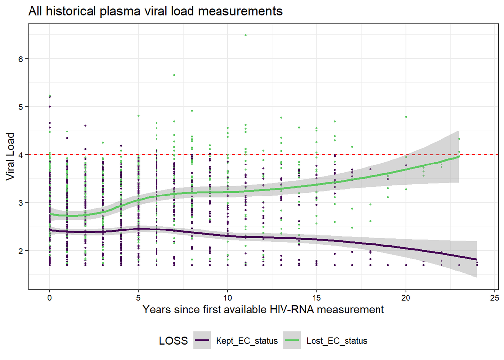

```r
#Dot plot
ggplot(data=dynamic_vl,aes(x=YEARS_SINCE_T0_ROUNDED,y=log10(RNA_c)))+
  geom_hline(yintercept=log10(10000), linetype="dashed", color = "red")+
  #geom_hline(yintercept=log10(550), linetype="dashed", color = "darkblue")+
  scale_color_manual(values=c("#440154","#5ec962")) +
  #geom_line(stat = 'identity',aes(colour=SampleID,group=SampleID))+
  theme_bw()+   theme(legend.position='bottom', axis.text = element_text(size = 8, color = "black"))+
  labs(title = "All historical plasma viral load measurements")+
  geom_point(aes(colour=LOSS),size = 0.5)+ #LOSS
  ylab("Viral Load")+
  xlab('Years since first available HIV-RNA measurement')+
  geom_smooth(aes(colour = LOSS), method = "loess", se = TRUE)
```

```r
ggsave(paste0(working_dir, "Outputs/Figure3A_LOSS_Dotplot_LOESS_Loss56_noLoss123_log10VL_time.pdf"),plot=last_plot(),
       width = 4, height =3, units = 'in', dpi = 300)
```

#### 0.2.1.1 Try out different definitions for loss

The definition of loss is >10,000 copies/mL. This makes a lot of sense and is clear for the story.

As sensitivity analyses, however, we should look at other definitions. If you look at the line plot 3A, at the purple dots/lines (persistent EC and VC), you see that from 10 years on, there are individuals who deviate strongly from the purple line and have increasing VL and are losing control. Only they start ART before they cross the threshold. We should find a definition that captures those individuals best, as well as EC. EC can barely lose control, because if an EC has increasing VL to >1,000c/mL, ART is usually started. Unless they actively refuse, no doctor treating an EC with increasing VL waits until >10,000 copies/mL.

Every definition suffers from the fact that we do not have measurements at fixed intervals, and number of measurements and time between vary greatly across individuals.

##### 0.2.1.1.1 Definition 1000c/mL increase in moving median VL

New definition is: 1000 copies/mL in the moving median relative to the moving median at T1_DATE, where moving median takes all VL measurements in 365 days before and 365 days after the measurement date. This definition does not suffer from isolated peaks and it is flexible with the number of measurements.

Source on calculating moving mean and median: https://epirhandbook.com/en/moving-averages.html

```r
# Create new df
df2 <- dynamic_vl
df2$LOGRNA_c <- log10(df2$RNA_c)

# test it out with one patient
test <- df2 %>% filter(PID == "SHM-EL-02134")
test <- test[,c(1,2,3,7,17)]
library(slider)
test$rollingmean <- slide_mean(test$RNA_c,before = 2, after = 2,na_rm = T)
test$rollingmean_index <- slide_index_mean(x = test$RNA_c, i = test$RNA_D, before = 365, after = 365, na_rm = T)
test$rollingmedian_index <- slide_index_dbl(.x = test$RNA_c, .i = test$RNA_D, .f = median, .before = 365, .after = 365)
test[,c(3:7)]
```

```
## # A tibble: 14 × 5
##    RNA_D      RNA_c YEARS_SINCE_HIV rollingmean rollingmean_index
##    <date>     <dbl>           <dbl>       <dbl>             <dbl>
##  1 2004-02-26  7530           0.180       3200              7530
##  2 2005-02-28  1070           1.19        2862.             1307.
##  3 2005-07-25  1000           1.59        2766              1575
##  4 2006-01-09  1850           2.05        1650              1650
##  5 2006-04-13  2380           2.31        2002              2002
##  6 2006-10-30  1950           2.86        2270              2270
##  7 2007-03-12  2830           3.22        2172              2375
##  8 2007-10-26  2340           3.84        2060              2120
##  9 2008-10-07  1360           4.79        2112              1932.
## 10 2009-03-11  1820           5.22        2498              3783.
## 11 2009-07-13  2210           5.56        3312              3783.
## 12 2009-10-12  4760           5.81        4268              4268
## 13 2009-12-29  6410           6.02        4880              4268
## 14 2010-03-03  6140           6.20        5770              4268
```

```r
# apply it to the entire dataset
df2 <- df2 %>% group_by(SampleID) %>% mutate(
  rollingmean_index = slide_index_mean(x = RNA_c, i = RNA_D, before = 365, after = 365, na_rm = T),
  rollingmedian_index = slide_index_dbl(.x = RNA_c, .i = RNA_D, .f = median, .before = 365, .after = 365))
```

##### 0.2.1.1.2 Define the moment of 1000 c/mL increase in moving median, relative to T1

We select only the measurements after T1. T1 is the sample date with proteomics data. We want to predict future increase in VL after the T1 sample.

```r
# only the VLs starting from T1
df3 <- df2 %>% group_by(SampleID) %>% filter(RNA_D >= (T1_DATE-30)) %>% # -30 days because sometimes the measurement is not completely congruous with T1_DATE
  # redefine oldest measurement
  group_by(SampleID) %>% mutate(OLDEST = min(RNA_D))

# define the starting median for each individual
df3 <- as.data.frame(df3) # change back from tibble to dataframe
for (id in df3$SampleID) { # for every ID
  rownums <- which(df3$SampleID == id) # rownumbers with all measurements
  df3[rownums,"startingvalue"] <- df3[min(rownums),"rollingmedian_index"] # the first row of this ID is the starting value
}

# define who experienced an increase of 1000 copies/mL in rollingmedian_index
df3$LOSS1000 <- NA
for (i in c(1:nrow(df3))){
  ID <- df3[i, "SampleID"]
  if (sum(df3[which(df3$SampleID == ID),"LOSS1000"],na.rm = T) == 0 &
      df3[i,"rollingmedian_index"] >= (df3[i,"startingvalue"] + 1000)){
    df3[i,"LOSS1000"] <- 1
  }
}

# add new loss category and date for every ID
df3$LOSS1000_EVER <- "PERSISTENT"
for (id in unique(df3$SampleID)) {
  if (sum(df3[which(df3$SampleID == id),"LOSS1000"],na.rm = T) > 0) { # if there is one LOSS
    df3[which(df3$SampleID == id),"LOSS1000_EVER"] <- "VL_INCREASE"
    df3[which(df3$SampleID == id),"LOSS1000_DATE"] <- df3[which(df3$SampleID == id & df3$LOSS1000 == 1),"RNA_D"]
  }
}
```

##### 0.2.1.1.3 Also define for EC the date they become detectable

```r
# flag the detectable dates after T1 for EC
df5 <- df3 %>% filter(NONVIREMIC == 1) %>% mutate(FIRSTDETECT = case_when(RNA_c > 50 ~ 1))
df5 <- as.data.frame(df5) # change back from tibble

# define EC who ever were detectable after T1 for EC
df5$FIRSTDETECT_DATE <- as.Date(NA)
df5$FIRSTDETECT_EVER <- NA
for (i in c(1:nrow(df5))){
  ID <- df5[i, "SampleID"]
  if (length(which(df5$SampleID == ID & !is.na(df5$FIRSTDETECT))) > 0){
    df5[i,"FIRSTDETECT_DATE"] <- df5[which(df5$SampleID == ID & !is.na(df5$FIRSTDETECT))[1],"RNA_D"]
    df5[i,"FIRSTDETECT_EVER"] <- 1
  } else {
    df5[i,"FIRSTDETECT_EVER"] <- 0
  }
}

# Double check the data
#df5[,c("SampleID","RNA_D","RNA_c","FIRSTDETECT","FIRSTDETECT_DATE","FIRSTDETECT_EVER")]
```

##### 0.2.1.1.4 Create hybrid definition

The definition of loss is reaching the first of two criteria: - VL reaching >10,000 copies/mL - >1000 copies/mL increase in moving median relative to T1 Where the moving median takes into account all measurements 1 year before to 1 year after viral load measurement.

```r
# in the dataset with only T1 measurements, create time variable time since T1 sample
df3$YEARS_SINCE_T1 <- as.numeric((df3$RNA_D - df3$T1_DATE)/365.25) # time in years since T1_DATE
df3$YEARS_SINCE_T1[which(df3$YEARS_SINCE_T1 <= 0)] <- 1/365.25 # at least one day for the cox regressions later

# make new hybrid definition
df3 <- df3 %>% mutate(LOSS_HYBRID = case_when(LOSS1000_EVER == "VL_INCREASE" | LOSS == "Lost_EC_status" ~ 1,
                                              LOSS1000_EVER == "PERSISTENT" & LOSS == "Kept_EC_status" ~ 0),
                      LOSS_HYBRID_DATE = case_when(
      LOSS1000_EVER == "VL_INCREASE" & LOSS != "Lost_EC_status" ~ LOSS1000_DATE,
      LOSS1000_EVER != "VL_INCREASE" & LOSS == "Lost_EC_status" ~ LOSS_DATE,
      LOSS1000_EVER == "VL_INCREASE" & LOSS == "Lost_EC_status" & LOSS_DATE <= LOSS1000_DATE ~ LOSS_DATE,
      LOSS1000_EVER == "VL_INCREASE" & LOSS == "Lost_EC_status" & LOSS1000_DATE < LOSS_DATE ~ LOSS1000_DATE
      )) %>% mutate_at(c("LOSS1000_EVER","LOSS_HYBRID"), as.factor)

# check whether the hybrid dates are correct
#df3[which(!is.na(df3$LOSS_HYBRID_DATE)),c(1,3,7,8,9,23,24,26,27)]

# join the new hybrid definition info with the dataframe that contains all measurements
df4 <- left_join(df2, unique(df3[,c("SampleID","LOSS1000_EVER","LOSS1000_DATE","LOSS_HYBRID","LOSS_HYBRID_DATE")]), by= "SampleID")

# how many have virological loss in the new definition?
temp <- unique(df4[,c("SampleID","LOSS1000_EVER","LOSS","LOSS_HYBRID")])
summary(temp$LOSS)
```

```
## Kept_EC_status Lost_EC_status
##            123             56
```

```r
summary(as.factor(temp$LOSS1000_EVER))
```

```
##  PERSISTENT VL_INCREASE
##          95          84
```

```r
table(temp$LOSS, temp$LOSS1000_EVER)
```

```
##
##                  PERSISTENT VL_INCREASE
##   Kept_EC_status         88          35
##   Lost_EC_status          7          49
```

```r
summary(as.factor(temp$LOSS_HYBRID))
```

```
##  0  1
## 88 91
```

### 0.2.2 make line plots with new definition of VL increase

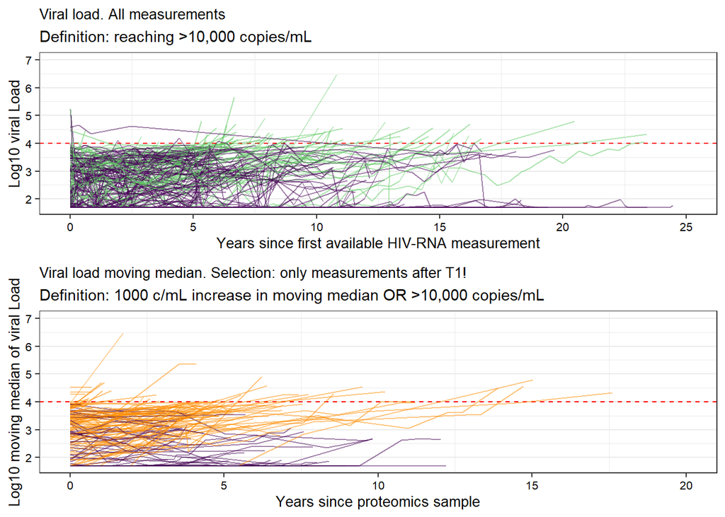

```r
g_hybrid <- ggplot(data=df3,aes(x=YEARS_SINCE_T1,y=log10(rollingmedian_index), group = SampleID))+
  geom_hline(yintercept=log10(10000), linetype="dashed", color = "red")+
  #geom_hline(yintercept=log10(550), linetype="dashed", color = "darkblue")+
  scale_color_manual(values=c("#440154","darkorange")) +
  theme_bw()+ theme(legend.position='none',
        panel.grid.major.x = element_blank(),
        axis.text = element_text(size = 8, color= "black"),
        axis.title = element_text(size = 10, color= "black",face = "plain"),
        plot.title = element_text(size = 10, color= "black"))+
  labs(title = "Viral load moving median. Selection: only measurements after T1!",
       subtitle = "Definition: 1000 c/mL increase in moving median OR >10,000 copies/mL")+
  geom_line(aes(colour=LOSS_HYBRID),alpha = 0.5,linewidth = 0.5)+ #LOSS_HYBRID
  #geom_point(aes(colour=LOSS_HYBRID), size = 0.5)+ #LOSS_HYBRID
  ylab("Log10 moving median of viral Load")+ xlab('Years since proteomics sample') +
  ylim(log10(50),7) + xlim(0,20)

## both but old definition
g_old <- ggplot(data=df4,aes(x=YEARS_SINCE_T0,y=log10(RNA_c), group = SampleID))+
  geom_hline(yintercept=log10(10000), linetype="dashed", color = "red")+
  #geom_hline(yintercept=log10(550), linetype="dashed", color = "darkblue")+
  scale_color_manual(values=c("#440154","#5ec962")) +
  theme_bw()+ theme(legend.position='none',
        panel.grid.major.x = element_blank(),
        axis.text = element_text(size = 8, color= "black"),
        axis.title = element_text(size = 10, color= "black",face = "plain"),
        plot.title = element_text(size = 10, color= "black"))+
  labs(title = "Viral load. All measurements",
       subtitle = "Definition: reaching >10,000 copies/mL")+
  geom_line(aes(colour=LOSS),alpha = 0.5,linewidth = 0.5)+
  ylab("Log10 viral Load")+ xlab('Years since first available HIV-RNA measurement') +
  ylim(log10(50),7) + xlim(0,25)

ggsave(paste0(working_dir, "Outputs/Supplements_FigureS4AB_LOSS_BOTHDEFINITIONS_Lineplot_Loss91_noLoss88_log10VL_afterT1_time.pdf")
       , gridExtra::grid.arrange(g_old, g_hybrid, ncol =1),
       scale = 1, width = 4, height =6, units = 'in', dpi = 300)
```

### 0.2.3 Define follow-up time and censoring for definition 2

I want to plot both the survival curve of the old definition and the new definition in the same KM plot.

Definition 1: reaching >10,000 copies/mL * Surv(FU_END, STATUS)

FU_END here is the smallest: LOSS_DATE then START_ART then LATEST_DATE

Definition 2: reaching >10,000 copies/mL OR a >1000 copies/mL increase in the moving median. * Surv(FU_END_HYBRID, LOSS_HYBRID)

Note that LOSS_HYBRID is already coded as 1 = event happened and 0 = event did not happen. FU_END_HYBRID here is the smallest: LOSS_HYBRID_DATE then START_ART then LATEST_DATE

```r
# add new definition
df_surv <- left_join(df, unique(df4[,c("SampleID", "LOSS_HYBRID","LOSS_HYBRID_DATE")]), by = "SampleID")
# also add the EC when they become 1st detectable after T1
df_surv <- left_join(df_surv, unique(df5[,c("SampleID","FIRSTDETECT_DATE","FIRSTDETECT_EVER")]), by = "SampleID")

# there are N=2 without longitudinal VL data
# df_surv[which(is.na(df_surv$LOSS_HYBRID))] # to double check the data
# these two have a VL_zenith of <50, and have always been undetectable (confirmed by clinicians).
# we can set their LOSS_HYBRID to 0 # note that one of these starts ART during FU
df_surv[which(is.na(df_surv$LOSS_HYBRID)),c("LOSS_HYBRID","FIRSTDETECT_EVER")] <- 0

# define the FU_END date for both definitions
df_surv <- df_surv %>% mutate(FU_END_check = case_when(LOSS == "Lost_EC_status" ~ LOSS_DATE,
                                                       LOSS == "Kept_EC_status" & ART == 1 ~ ART_START,
                                                       LOSS == "Kept_EC_status" & ART == 0 ~ LATEST_DATE),
                              FU_END_DATE_HYBRID = case_when(LOSS_HYBRID == 1 ~ LOSS_HYBRID_DATE,
                                                       LOSS_HYBRID == 0 & ART == 1 ~ ART_START,
                                                       LOSS_HYBRID == 0 & ART == 0 ~ LATEST_DATE),)

# double check if all FU_END dates are the same
which(df_surv$FU_END_DATE != df_surv$FU_END_check)
```

```
## integer(0)
```

```r
# with the new definition, the survival time FU_END has been changed in N=61 individuals
#df_surv[which(df_surv$FU_END_DATE != df_surv$FU_END_DATE_HYBRID),c(1,6,7,8,9,29:33)] # to check the data

# recalculate time FU_END for both definitions in days
df_surv <- df_surv %>% mutate(FU_END2 = as.numeric((FU_END_DATE - T1_DATE)),
                              FU_END_HYBRID = as.numeric((FU_END_DATE_HYBRID - T1_DATE)))

# add FU_END_FULL for full history follow-up time
df_surv <- df_surv %>% mutate(FU_END_FULL = as.numeric((FU_END_DATE - HIV_D)),
                              FU_END_HYBRID_FULL = as.numeric((FU_END_DATE_HYBRID - HIV_D)))

# double check if this is the same as before
# df_surv[which(df_surv$FU_END != df_surv$FU_END2),c("SampleID","FU_END","FU_END2")]

# double check the n=61 participants for whom the FU_END is different across definitions
# df_surv[which(df_surv$FU_END_DATE != df_surv$FU_END_DATE_HYBRID),c("T1_DATE","FU_END_DATE", "FU_END", "FU_END_HYBRID", "FU_END_DATE_HYBRID")]

# Add a log10 VL for T1
df_surv$LOG10T1_VL <- df_surv$T1_VL
df_surv <- df_surv %>% mutate(LOG10T1_VL = case_when(LOG10T1_VL <= 50 ~ log10(50),
                                 LOG10T1_VL >50 ~ log10(LOG10T1_VL)))
```

## 0.3 Estimate the loss-free follow-up with kaplan-meier

```r
library(survminer)
library(survival)
```

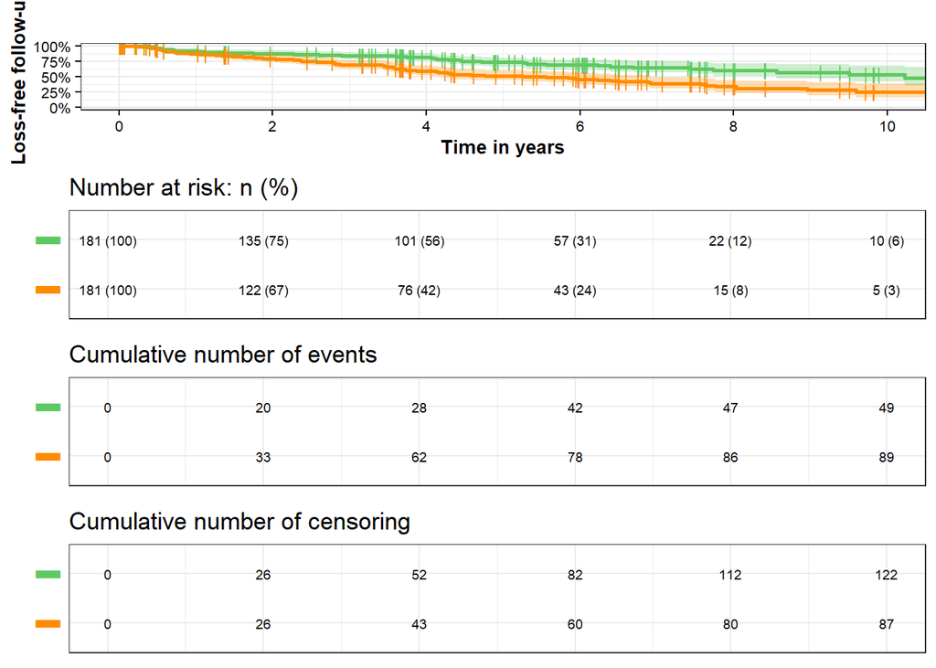

```r
# create dataset with definition 1
dfsurv1 <- df_surv %>% mutate(DEFINITION = "1",
                             TIME = FU_END,
                             STATUS = case_when(LOSS == "Kept_EC_status" ~ 0,
                                                LOSS == "Lost_EC_status" ~ 1))
# create dataset with definition 2
dfsurv2 <- df_surv %>% mutate(DEFINITION = "2",
                             TIME = FU_END_HYBRID,
                             STATUS = case_when(LOSS_HYBRID == 0 ~ 0,
                                                LOSS_HYBRID == 1 ~ 1))
dfkm <- rbind(dfsurv1,dfsurv2)

km1_fit <- survfit(Surv(dfkm[,"TIME"], dfkm[,"STATUS"]) ~ as.factor(dfkm[,"DEFINITION"]), data=dfkm) # use ~1 if you want to indicate there is no grouping variable.

km1 <- ggsurvplot(km1_fit,censor.size=3, censor.shape=124,conf.int = T,
           surv.scale = "percent", xlim = c(0,10*365.25), #ylim = c(0.75,1),
            break.y.by = 0.25, # y-axis tick marks
            break.x.by = 365.25*2, # x-axis tick marks
            xscale = "d_y", # transform labels from days to years
            ylab = "Loss-free follow-up", font.y = c(10,"bold","black"),
            xlab = "Time in years", font.x = c(10,"bold","black"),
            font.tickslab = c(8,"plain","black"),
            title = "", #"Follow-up without virological loss", font.title = c(10,"italic","black"),
            legend = "none",
            ggtheme = theme_bw(),
            cumevents = TRUE, # table for cumulative events
           fontsize = 2.5,
           cumcensor = TRUE, # table for cumulative censoring
                  risk.table = "abs_pct", # absolute with percentage
                  tables.height = 0.25, # default is 0.25
                  palette = c("#5ec962","darkorange"), # add multiple colors if more group levels
                  #risk.table.fontsize =1.5, # redundant because of fontsize argument above
                  tables.theme = clean_theme(),
                  tables.y.text = F)
km1
```

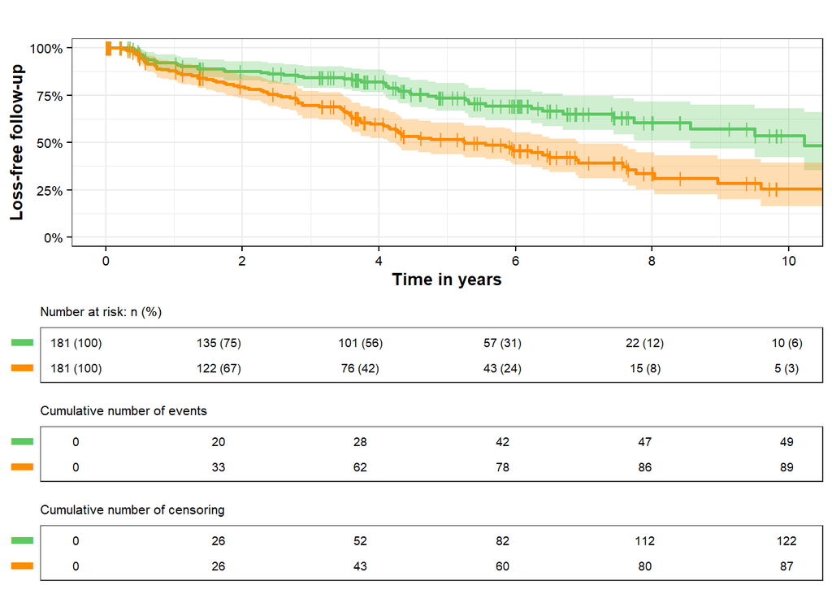

```r
km1.1 <- gridExtra::grid.arrange(km1$plot,
                                 km1$table + theme(plot.title = element_text(size = 8,face="plain"), panel.grid = element_line(colour="white")),
                                 km1$cumevents + theme(plot.title = element_text(size = 8,face="plain"), panel.grid = element_line(colour="white")),
                                 km1$ncensor.plot + theme(plot.title = element_text(size = 8,face="plain"), panel.grid = element_line(colour="white")),
                               layout_matrix = cbind(c(1,1,1,1,1,1,2,2,3,3,4,4)))
```

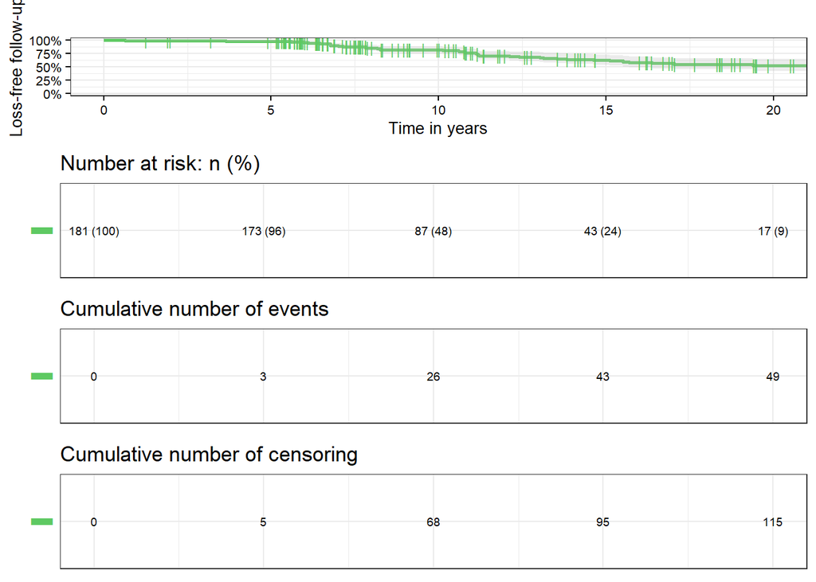

```r
#ggsave(paste0(working_dir, "Outputs/LOSS_BOTHDEFINITIONS_KaplanMeier_Loss91_56_noLoss80_125_.pdf")
#       ,km1.1,
#       scale = 1, width = 4, height =5, units = 'in', dpi = 300)


# create dataset with definition 1 but now full follow-up
dfsurv1.1 <- df_surv %>% mutate(DEFINITION = "1",
                             TIME = FU_END_FULL,
                             STATUS = case_when(LOSS == "Kept_EC_status" ~ 0,
                                                LOSS == "Lost_EC_status" ~ 1))

km1_fit <- survfit(Surv(dfsurv1.1[,"TIME"], dfsurv1.1[,"STATUS"]) ~ 1, data=dfsurv1.1) # use ~1 if you want to indicate there is no grouping variable.

km1 <- ggsurvplot(km1_fit,censor.size=3, censor.shape=124,conf.int = T,
           surv.scale = "percent", xlim = c(0,20*365.25), #ylim = c(0.75,1),
            break.y.by = 0.25, # y-axis tick marks
            break.x.by = 365.25*5, # x-axis tick marks
            xscale = "d_y", # transform labels from days to years
            ylab = "Loss-free follow-up", font.y = c(10,"plain","black"),
            xlab = "Time in years", font.x = c(10,"plain","black"),
            font.tickslab = c(8,"plain","black"),
            title = "", #"Follow-up without virological loss", font.title = c(10,"italic","black"),
            legend = "none",
            ggtheme = theme_bw(),
            cumevents = TRUE, # table for cumulative events
           fontsize = 2.5,
           cumcensor = TRUE, # table for cumulative censoring
                  risk.table = "abs_pct", # absolute with percentage
                  tables.height = 0.25, # default is 0.25
                  palette = c("#5ec962"), # add multiple colors if more group levels
                  #risk.table.fontsize =1.5, # redundant because of fontsize argument above
                  tables.theme = clean_theme(),
                  tables.y.text = F)
km1
```

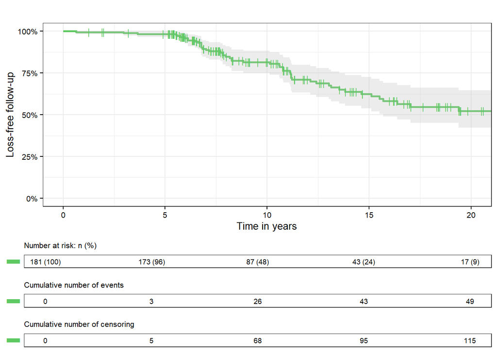

```r
km1.1 <- gridExtra::grid.arrange(km1$plot,
                                 km1$table + theme(plot.title = element_text(size = 8,face="plain"), panel.grid = element_line(colour="white")),
                                 km1$cumevents + theme(plot.title = element_text(size = 8,face="plain"), panel.grid = element_line(colour="white")),
                                 km1$ncensor.plot + theme(plot.title = element_text(size = 8,face="plain"), panel.grid = element_line(colour="white")),
                               layout_matrix = cbind(c(1,1,1,1,1,1,2,3,4)))
```

```r
ggsave(paste0(working_dir, "Outputs/Figure3B_LOSS_KaplanMeier_Loss56_noLoss125_.pdf")
       ,km1.1,
       scale = 1, width = 4, height =4, units = 'in', dpi = 300)
```

### 0.3.1 Cox regression, corrected for AGE, SEX, STORAGE_TIME, CENTER_EMC, CENTER_OLVG, CENTER_UMCU

We will run cox regression for both definitions.

Remember:

Definition 1: reaching >10,000 copies/mL * Surv(FU_END, LOSS == “Lost_EC_status”)

Definition 2: reaching >10,000 copies/mL OR a >1000 copies/mL increase in the moving median. * Surv(FU_END_HYBRID, LOSS_HYBRID)

```r
summary.factor(df_surv$LOSS)
```

```
## Kept_EC_status Lost_EC_status
##            125             56
```

```r
summary.factor(df_surv$LOSS_HYBRID)
```

```
##  0  1
## 90 91
```

```r
table(df_surv$LOSS_HYBRID, df_surv$NONVIREMIC)
```

```
##
##      0  1
##   0 58 32
##   1 87  4
```

```r
# Join with processed clinical data
dfcox1 <- df_surv %>%
  mutate(TIME = FU_END,
         STATUS = case_when(LOSS == "Kept_EC_status" ~ 0,
                            LOSS == "Lost_EC_status" ~ 1))
dfcox2 <- df_surv %>%
  mutate(TIME = FU_END_HYBRID,
         STATUS = case_when(LOSS_HYBRID == 0 ~ 0,
                            LOSS_HYBRID == 1 ~ 1))


###### addendum 24-10-2024 to export prepared data as RDS object
tempdir <- "C:/Users/accou/Downloads/" #"C:/Users/accou/Documents/PHD_2_projects/7_Predictionmodels_SHMOlink/Input/"

saveRDS(df_surv, file = paste0(tempdir, "OlinkATHENA_ARTnaiveECVC_clinical_prepared.rds"))
saveRDS(dfcox1, file = paste0(tempdir, "OlinkATHENA_ARTnaiveECVC_viralloss_prepared.rds"))
saveRDS(dfcox2, file = paste0(tempdir, "OlinkATHENA_ARTnaiveECVC_hybriddefinition_prepared.rds"))
rm(tempdir)
######

# double check the survival items: # this is the most important thing: TIME and STATUS must be coded correctly and the survival item must have the format of time (in this case in days) with an additional "+" sign if event happened (in this case, virological loss)
Surv(dfcox1[,"TIME"],dfcox1[,"STATUS"])
```

```
##   [1]  184+ 1349+ 1015+  153   505+ 2512+ 2826    78+ 5075   223   120+ 2518+
##  [13] 1512  2220+  259  1938    22+ 2173+ 2485+ 1351+ 3336+ 2377+ 1274  1159+
##  [25] 1941  1855+ 1498  2921+ 1552+ 1722   205  1365  1485  2003+  148+ 2380+
##  [37] 2786+ 6432   630  1381+ 1919+ 2336   937+ 1581+ 1765  1781+  870   210
##  [49]   13+  950  2878+ 3592+ 1882+ 3126   490  1591+ 2716  1802+ 1219+ 2202+
##  [61]  181   184   413+  721+ 4402+ 1338+ 2213+ 1350+  502+   29+ 1334+   84+
##  [73] 2797+ 3551+   22+   15+  403  4095     7+ 4049  2259+ 1792+ 2206+ 2555+
##  [85] 1561  3074+ 4077+  376+ 1398+ 2186+ 3069+  895+ 1679+ 2311+ 1624  1682+
##  [97] 3586+ 2705+  146  1631  1191+ 2071+ 4494+ 1595+ 1315+ 1026  3737  1442+
## [109] 2031  2410+ 2758+  636     9+ 1204+ 1056  1976+  385  2182+ 1687+ 1403+
## [121] 1634+ 2445     5+ 2375+ 1484+ 3429+ 1145+ 1970+ 3612+ 2764+  376   130+
## [133]  273   174+ 1322+ 1341+ 1920  2467+ 2929+    8+  520+ 1158+ 5488  1382+
## [145] 2363+  491  2275  3471  2113+ 1782+ 1148+ 2716+  181+  196   265   163
## [157] 2226+ 1567  1387+ 2583+ 1499    13+ 5374  1352+ 2256+ 2159+  213+ 1593+
## [169] 1316  2519+ 1785+ 1987+ 1278+ 2724+ 2472+  828  1597+  180   506+ 3473+
## [181] 1537+
```

```r
Surv(dfcox2[,"TIME"],dfcox2[,"STATUS"])
```

```
##   [1]  184+ 1349+ 1015+  153   505+ 2512+ 1302    78+ 5075   223   120+ 1918
##  [13] 1050  2220+  259  1363    22+ 2173+ 2485+ 1351+ 1911  2377+  336  1159+
##  [25] 1582  1673  1018  2921+ 1552+ 1414   205  1365  1485   133   148+ 2165
##  [37] 2786+ 3505   630  1381+ 1919+ 2336   642  1581+ 1741   204   870   210
##  [49]   13+  574  2878+ 3592+ 1882+ 2766   490  1549  2514  1507  1219+ 2137
##  [61]  181   184   413+  721+ 4402+ 1338+ 2213+  272   502+   29+ 1334+   84+
##  [73] 2797+ 3551+   22+   15+  403  2793     7+ 2936  2259+ 1792+ 1570  2526
##  [85]  590  3074+ 4077+  376+ 1360  2186+ 1052   895+  937  2311+ 1310   863
##  [97] 3586+  843   146  1289  1141  2071+ 4494+ 1595+ 1315+ 1026  2372  1442+
## [109] 2031  2410+ 1029   295     9+ 1204+  742  1274   385  2182+ 1687+ 1315
## [121]  765  1259     5+ 2375+ 1484+ 3429+  109  1970+ 2834  2764+  376   130+
## [133]  273   174+  683  1341+ 1023  2467+ 2929+    8+  520+ 1158+ 3272  1382+
## [145] 2363+  491  2275   917  2113+   91   707  2716+  181+  196   265   163
## [157] 2177  1254  1387+ 2583+  537    13+ 5374   457  2256+ 2159+  213+ 1562
## [169] 1316  1269  1585  1987+ 1278+ 2724+  985   828  1597+  180   506+ 3473+
## [181] 1519
```

```r
# Run Cox regression definition 1
olinkcolumns2 <- c(grep("GP2",colnames(dfcox1)):grep("NFU1",colnames(dfcox1)))
res1 <- data.frame()
for (i in olinkcolumns2) {
    cox.res <- coxph(Surv(dfcox1[,"TIME"],dfcox1[,"STATUS"]) ~ dfcox1[,i]
                     + SEX + AGE + CENTER_EMC + CENTER_OLVG + CENTER_UMCU + STORAGE_TIME,
                     data = dfcox1)
    x <- summary(cox.res)

    newrow =
        cbind(
        as.data.frame(colnames(dfcox1)[i], nm = "PROTEIN"), # protein name
        as.data.frame(x$coef[1,"coef"],nm = "BETA"), # beta
        as.data.frame(x$coef[1,"exp(coef)"],nm = "HR"), # Hazard ratio
        as.data.frame(x$conf.int[1,"lower .95"],nm = "LOWER"),
        as.data.frame(x$conf.int[1,"upper .95"],nm = "UPPER"), # 95% CI of the Hazard ratio
        as.data.frame(x$coef[1,"Pr(>|z|)"], nm = "RAW_P") # P-value of coefficient
        )
    res1 <- rbind(res1,newrow)
}
res1$FDR_P <- p.adjust(res1$RAW_P, method = 'BH')
res1[order(res1$FDR_P),]
```

```
##                PROTEIN          BETA        HR      LOWER      UPPER
## 191              ICAM3  1.6821493285 5.3771007 2.57518665 11.2276181
## 496             SH2D1A  0.5206565545 1.6831324 1.32584424  2.1367024
## 1186             CRTAM  1.0248555675 2.7866929 1.67579004  4.6340278
## 1757             C1QL2  0.8839666377 2.4204819 1.55298100  3.7725719
## 1983             CNGB3 -1.2399276078 0.2894052 0.15616950  0.5363106
## 19                GZMH  0.3133742126 1.3680334 1.15858843  1.6153409
## 1625              LCP1  0.9190673429 2.5069512 1.51965161  4.1356875
## 1555              ASPN -0.9073917696 0.4035755 0.24387089  0.6678663
## 1389           EXOSC10  0.5007897697 1.6500239 1.23871775  2.1979009
## 264             PDGFRB -1.2265754105 0.2932953 0.14246446  0.6038146
## 710          ADCYAP1R1 -1.5304839163 0.2164309 0.08859122  0.5287470
## 1665             PTPRC  1.3971431507 4.0436314 1.77564766  9.2084456
## 2155             KLRK1  0.9229689494 2.5167514 1.45510899  4.3529644
## 569                CD6  0.6154637802 1.8505146 1.27822078  2.6790398
```

[output cut: 4827 more lines]

```r
# Run Cox regression definition 2
olinkcolumns2 <- c(grep("GP2",colnames(dfcox2)):grep("NFU1",colnames(dfcox2)))
res2 <- data.frame()
for (i in olinkcolumns2) {
    cox.res <- coxph(Surv(dfcox2[,"TIME"],dfcox2[,"STATUS"]) ~ dfcox2[,i]
                     + SEX + AGE + CENTER_EMC + CENTER_OLVG + CENTER_UMCU + STORAGE_TIME,
                     data = dfcox2)
    x <- summary(cox.res)

    newrow =
        cbind(
        as.data.frame(colnames(dfcox2)[i], nm = "PROTEIN"), # protein name
        as.data.frame(x$coef[1,"coef"],nm = "BETA"), # beta
        as.data.frame(x$coef[1,"exp(coef)"],nm = "HR"), # Hazard ratio
        as.data.frame(x$conf.int[1,"lower .95"],nm = "LOWER"),
        as.data.frame(x$conf.int[1,"upper .95"],nm = "UPPER"), # 95% CI of the Hazard ratio
        as.data.frame(x$coef[1,"Pr(>|z|)"], nm = "RAW_P") # P-value of coefficient
        )
    res2 <- rbind(res2,newrow)
}
res2$FDR_P <- p.adjust(res2$RAW_P, method = 'BH')
res2[order(res2$FDR_P),]
```

```
##                PROTEIN          BETA        HR      LOWER     UPPER
## 191              ICAM3  1.345674e+00 3.8407747 2.25267302 6.5484650
## 585                LY9  1.143631e+00 3.1381422 1.84272309 5.3442302
## 1186             CRTAM  7.809280e-01 2.1834976 1.51674844 3.1433438
## 569                CD6  5.794707e-01 1.7850934 1.34983830 2.3606964
## 613               CD48  1.025265e+00 2.7878340 1.63683616 4.7481956
## 1625              LCP1  6.741815e-01 1.9624260 1.37462046 2.8015849
## 536              KLRD1  6.728217e-01 1.9597594 1.36600363 2.8116009
## 901               LAG3  6.424834e-01 1.9011965 1.33709944 2.7032754
## 1359             FCRL5  5.106107e-01 1.6663086 1.25870051 2.2059133
## 1665             PTPRC  1.203362e+00 3.3312993 1.73360979 6.4014148
## 1136            PPP3R1 -7.845293e-01 0.4563345 0.29530503 0.7051730
## 568               GZMA  6.411448e-01 1.8986532 1.31890923 2.7332312
## 825              GFRA2 -1.475715e+00 0.2286151 0.09907799 0.5275125
## 496             SH2D1A  3.070878e-01 1.3594604 1.13772854 1.6244055
```

[output cut: 4827 more lines]

### 0.3.2 Volcano plots

```r
library(ggrepel)
head(res1)
```

```
##    PROTEIN         BETA        HR     LOWER    UPPER     RAW_P     FDR_P
## 1      GP2 -0.083246496 0.9201243 0.6785131 1.247771 0.5922040 0.9988032
## 2    WASF1  0.134491899 1.1439554 0.9107903 1.436812 0.2474893 0.9422438
## 3      HK2  0.060670396 1.0625486 0.8063797 1.400097 0.6664383 0.9988032
## 4   VSTM2L  0.040080701 1.0408948 0.6343207 1.708067 0.8739759 0.9988032
## 5     TIA1 -0.004044887 0.9959633 0.8507774 1.165925 0.9598703 0.9988032
## 6 MPHOSPH8  0.055914204 1.0575069 0.8205934 1.362820 0.6656939 0.9988032
```

```r
head(res2)
```

```
##    PROTEIN        BETA        HR     LOWER    UPPER     RAW_P     FDR_P
## 1      GP2  0.02709151 1.0274618 0.8234068 1.282085 0.8104590 0.9253265
## 2    WASF1 -0.07858903 0.9244198 0.7627564 1.120347 0.4229587 0.7284060
## 3      HK2 -0.04065938 0.9601561 0.7651025 1.204936 0.7256422 0.8909458
## 4   VSTM2L  0.06618169 1.0684208 0.7160103 1.594283 0.7458715 0.8968589
## 5     TIA1 -0.10358050 0.9016034 0.7942948 1.023409 0.1091409 0.4965105
## 6 MPHOSPH8 -0.09498674 0.9093850 0.7377521 1.120947 0.3734206 0.6912266
```

```r
# add a grouping column for coloring by significance; default value is "not significant"
res1 <- res1 %>% mutate(group= case_when(FDR_P < 0.05 ~ "FDR Significant",
                                               RAW_P < 0.05 & FDR_P > 0.05 ~ "Nominal Significant",
                                               RAW_P > 0.05 ~ "NotSignificant"
                                               ))

# add a text label if 'FDR-P <0.05', or if 'RAW-P <0.05 but HR >2', or if CRTAM, LY9, CD6, VAT1.
for (i in 1:nrow(res1)){
  if(res1$FDR_P[i] < 0.05 | # 'FDR-P <0.05'
     res1$FDR_P[i] < 0.1 |
     #(res1$RAW_P[i] < 0.001 & res1$HR[i] > 3) | # 'RAW-P <0.05 but HR >3'
     #(res1$RAW_P[i] < 0.001 & res1$HR[i] <0.3) | # 'RAW-P <0.05 but HR <0.3'
     (res1$PROTEIN[i] %in% c("CRTAM","LY9","CD6","VAT1") # CRTAM, LY9, CD6, VAT1
     ))
  {res1$LABEL[i] <- res1$PROTEIN[i]} else
  {res1$LABEL[i] <- ""}}
res1
```

```
##                PROTEIN          BETA        HR      LOWER      UPPER
## 1                  GP2 -0.0832464956 0.9201243 0.67851306  1.2477708
## 2                WASF1  0.1344918987 1.1439554 0.91079027  1.4368115
## 3                  HK2  0.0606703961 1.0625486 0.80637973  1.4000967
## 4               VSTM2L  0.0400807007 1.0408948 0.63432066  1.7080666
## 5                 TIA1 -0.0040448874 0.9959633 0.85077737  1.1659253
## 6             MPHOSPH8  0.0559142037 1.0575069 0.82059336  1.3628199
## 7               HNRNPK  0.0499538449 1.0512226 0.88852462  1.2437122
## 8                CEBPB  0.0398111707 1.0406143 0.65656159  1.6493168
## 9                  VIM  0.1384521202 1.1484947 0.80447446  1.6396295
## 10               CHEK2  0.1872109819 1.2058817 0.87229792  1.6670344
## 11               CRHR1 -0.0048968069 0.9951152 0.79507240  1.2454893
## 12                TSLP  0.4287333226 1.5353115 1.09252144  2.1575609
## 13               MFAP3 -0.1289778591 0.8789934 0.63641889  1.2140266
## 14                CTF1 -0.0029398803 0.9970644 0.79573398  1.2493340
```

[output cut: 4827 more lines]

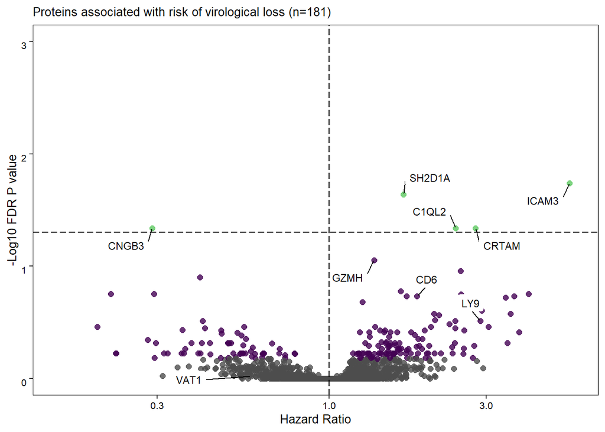

```r
# make the volcano plot
options(ggrepel.max.overlaps = Inf)
ggplot(res1, aes(x=HR, y=-log10(FDR_P))) +
  geom_point(aes(color=group), alpha=0.8, size=2) +
  scale_color_manual(values=c("#5ec962","#440154","#4d4d4d")) +
  theme_bw() + # size of plotting window
  theme(legend.background=element_rect(),
        plot.title=element_text(angle=0, size=10, face="plain", vjust=1),
        panel.grid.major=element_blank(), #Remove gridlines
        panel.grid.minor=element_blank(), #Remove gridlines
        axis.text.x=element_text(angle=0, size=8, color= "black", vjust=1),
        axis.text.y=element_text(angle=0, size=8, color= "black", vjust=1),
        axis.title=element_text(size=10),
        legend.position = "none") +
  # guides(colour = guide_legend(override.aes=list(size=2.5))) + #  Change the size of the icons/symbols in the legend
  xlab("Hazard Ratio") +
  ylab("-Log10 FDR P value") +
  scale_x_continuous(trans = 'log10', limits = c(0.15,5.5)) +
  ggtitle("Proteins associated with risk of virological loss (n=181)" ) +
  geom_label_repel(  #Add the text labels
    label.size = NA, #Size of label border, in mm.
    box.padding = unit(0.45, "lines"),
    label.padding = 0.25, # Amount of padding around label, as unit or number.
    label.r = 0.15, #Radius of rounded corners,
    size = 3, aes(label = LABEL,hjust = .5))+
  ylim(0, 3) + # limits of the graph
  geom_vline(xintercept=c(1), linetype="longdash", colour="black", linewidth=0.4) + # Add a vertical line for Estimate change cut-offs
  geom_hline(yintercept=-log10(0.05), linetype="longdash", colour="black", linewidth=0.4) #Add a horizontal line for P-value cut-off
```

```r
ggsave(paste0(working_dir, "Outputs/Figure3C_LOSS_VIRLOSSCOX_Volcano_label_0.05FDRP_0.05RAWP2HR_agesexcenterstorage.pdf"), plot = last_plot(), device = NULL, path = NULL,scale = 1, width = 4, height =3.5, units = 'in', dpi = 300)

####### and now for the second definition
# add a grouping column for coloring by significance; default value is "not significant"
res2 <- res2 %>% mutate(group= case_when(FDR_P < 0.05 ~ "FDR Significant",
                                               RAW_P < 0.05 & FDR_P > 0.05 ~ "Nominal Significant",
                                               RAW_P > 0.05 ~ "NotSignificant"
                                               ))

# add a text label if 'FDR-P <0.05', or if 'RAW-P <0.05 but HR >2', or if CRTAM, LY9, CD6, VAT1.
for (i in 1:nrow(res2)){
  if(res2$FDR_P[i] < 0.05 | # 'FDR-P <0.05'
          res2$FDR_P[i] < 0.1 |
     #(res2$RAW_P[i] < 0.01 & res2$HR[i] > 3) | # 'RAW-P <0.05 but HR >3'
     #(res2$RAW_P[i] < 0.01 & res2$HR[i] <0.3) | # 'RAW-P <0.05 but HR <0.3'
     (res2$PROTEIN[i] %in% c("CRTAM","LY9","CD6","VAT1") # CRTAM, LY9, CD6, VAT1
     ))
  {res2$LABEL[i] <- res2$PROTEIN[i]} else
  {res2$LABEL[i] <- ""}}
res2[order(res2$FDR_P),]
```

```
##                PROTEIN          BETA        HR      LOWER     UPPER
## 191              ICAM3  1.345674e+00 3.8407747 2.25267302 6.5484650
## 585                LY9  1.143631e+00 3.1381422 1.84272309 5.3442302
## 1186             CRTAM  7.809280e-01 2.1834976 1.51674844 3.1433438
## 569                CD6  5.794707e-01 1.7850934 1.34983830 2.3606964
## 613               CD48  1.025265e+00 2.7878340 1.63683616 4.7481956
## 1625              LCP1  6.741815e-01 1.9624260 1.37462046 2.8015849
## 536              KLRD1  6.728217e-01 1.9597594 1.36600363 2.8116009
## 901               LAG3  6.424834e-01 1.9011965 1.33709944 2.7032754
## 1359             FCRL5  5.106107e-01 1.6663086 1.25870051 2.2059133
## 1665             PTPRC  1.203362e+00 3.3312993 1.73360979 6.4014148
## 1136            PPP3R1 -7.845293e-01 0.4563345 0.29530503 0.7051730
## 568               GZMA  6.411448e-01 1.8986532 1.31890923 2.7332312
## 825              GFRA2 -1.475715e+00 0.2286151 0.09907799 0.5275125
## 496             SH2D1A  3.070878e-01 1.3594604 1.13772854 1.6244055
```

[output cut: 4827 more lines]

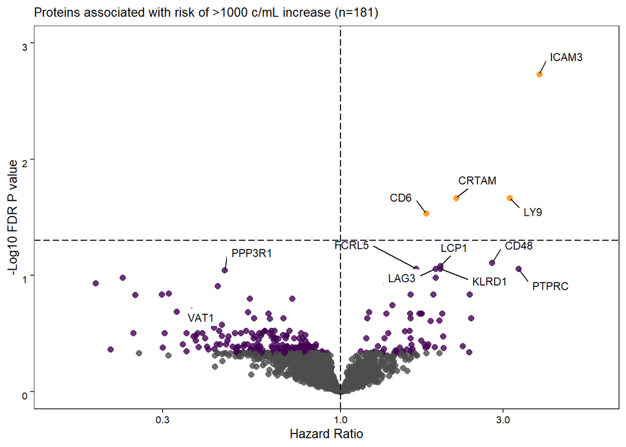

```r
# make the volcano plot
options(ggrepel.max.overlaps = Inf)
ggplot(res2, aes(x=HR, y=-log10(FDR_P))) +
  geom_point(aes(color=group), alpha=0.8, size=2) +
  scale_color_manual(values=c("darkorange","#440154","#4d4d4d")) +
  theme_bw() + # size of plotting window
  theme(legend.background=element_rect(),
        plot.title=element_text(angle=0, size=10, face="plain", vjust=1),
        panel.grid.major=element_blank(), #Remove gridlines
        panel.grid.minor=element_blank(), #Remove gridlines
        axis.text.x=element_text(angle=0, size=8, color= "black", vjust=1),
        axis.text.y=element_text(angle=0, size=8, color= "black", vjust=1),
        axis.title=element_text(size=10),
        legend.position = "none") +
  # guides(colour = guide_legend(override.aes=list(size=2.5))) + #  Change the size of the icons/symbols in the legend
  xlab("Hazard Ratio") +
  ylab("-Log10 FDR P value") +
  scale_x_continuous(trans = 'log10', limits = c(0.15,5.5)) +
  ggtitle("Proteins associated with risk of >1000 c/mL increase (n=181)" ) +
  geom_label_repel(  #Add the text labels
    label.size = NA, #Size of label border, in mm.
    box.padding = unit(0.45, "lines"),
    label.padding = 0.25, # Amount of padding around label, as unit or number.
    label.r = 0.15, #Radius of rounded corners,
    size = 3, aes(label = LABEL,hjust = .5))+
  ylim(0, 3) + # limits of the graph
  geom_vline(xintercept=c(1), linetype="longdash", colour="black", linewidth=0.4) + # Add a vertical line for Estimate change cut-offs
  geom_hline(yintercept=-log10(0.05), linetype="longdash", colour="black", linewidth=0.4) #Add a horizontal line for P-value cut-off
```

```r
ggsave(paste0(working_dir, "Outputs/Figure3C_LOSS_VLINCREASECOX_Volcano_label_0.05FDRP_0.05RAWP2HR_agesexcenterstorage.pdf"), plot = last_plot(), device = NULL, path = NULL,scale = 1, width = 4, height =3.5, units = 'in', dpi = 300)

# write results to excel file
openxlsx::write.xlsx(res1,paste0(working_dir, "Outputs/Supplements_LOSS_Cox_VIRLOSS_125Kept_vs_56Lost_2420_agesexcenterstorage.xlsx"))
openxlsx::write.xlsx(res2,paste0(working_dir, "Outputs/Supplements_LOSS_Cox_VLINCREASE_90Kept_vs_91Lost_2420_agesexcenterstorage.xlsx"))

###### addendum 24-10-2024 to export prepared data as RDS object
tempdir <- "C:/Users/accou/Downloads/" #"C:/Users/accou/Documents/PHD_2_projects/7_Predictionmodels_SHMOlink/Input/"

saveRDS(res1, file = paste0(tempdir, "OlinkATHENA_ARTnaiveECVC_viralloss_coxregr_sumstats.rds"))
saveRDS(res2, file = paste0(tempdir, "OlinkATHENA_ARTnaiveECVC_hybriddefinition_coxregr_sumstats.rds"))
rm(tempdir)
######
```

## 0.4 ADD CD4 DYNAMICS

### 0.4.1 Read cleaned data

```r
cd4_T1_500 <- readRDS(paste0(working_dir, "Inputs/AthenaOlink_Longitudinal_Cd4Counts_Cleaned.rds"))
```

## 0.5 Dot plot and line plot

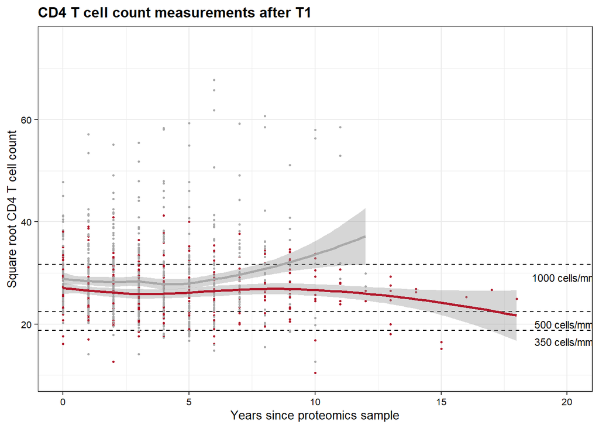

```r
#Dot plot
ggplot(data=cd4_T1_500,aes(x=YEARS_SINCE_T1_ROUNDED,y=sqrt(CD4A)))+
  geom_hline(yintercept=sqrt(350), linetype="dashed", color = "black")+
  geom_hline(yintercept=sqrt(500), linetype="dashed", color = "black")+
    geom_hline(yintercept=sqrt(1000), linetype="dashed", color = "black")+
  scale_color_manual(values=c("darkgrey","#b2182b")) +
  #geom_line(stat = 'identity',aes(colour=SampleID,group=SampleID))+
  theme_bw()+   theme(legend.position='none',
                      plot.title = element_text(size = 12, color= "black", face = "bold"),
                      axis.title = element_text(size = 10, color = "black"),
                      axis.text = element_text(size = 8, color = "black")) +
  geom_point(aes(colour=LOSS),size = 0.5)+ #LOSS
  ylim(10,75) + xlim(0,20) +
  labs(title = "CD4 T cell count measurements after T1")+
  ylab("Square root CD4 T cell count")+
  xlab('Years since proteomics sample')+
  geom_smooth(aes(colour = LOSS), method = "loess", se = TRUE) +
  annotate("text", x=20, y=sqrt(275), label="350 cells/mm3", size = 3, color = "black") +
  annotate("text", x=20, y=sqrt(400), label="500 cells/mm3", size = 3, color = "black") +
  annotate("text", x=20, y=sqrt(850), label="1000 cells/mm3", size = 3, color = "black")
```

```r
ggsave(paste0(working_dir, "Outputs/Supplements_FigureS4D_IMMULOSS_Dotplot_LOESS_Loss42_noLoss96_CD4_time.pdf"),plot=last_plot(),
       width = 4, height =3, units = 'in', dpi = 300)
temp <- unique(cd4_T1_500[,c("SampleID","IMMU_LOSS_EVER")])
summary(as.factor(temp$IMMU_LOSS_EVER))
```

```
##  0  1
## 96 42
```

```r
"#b2182b"
```

```
## [1] "#b2182b"
```

Make a gridarrange ggplot with duplicate plots, to get the same image proportions as with virological loss.

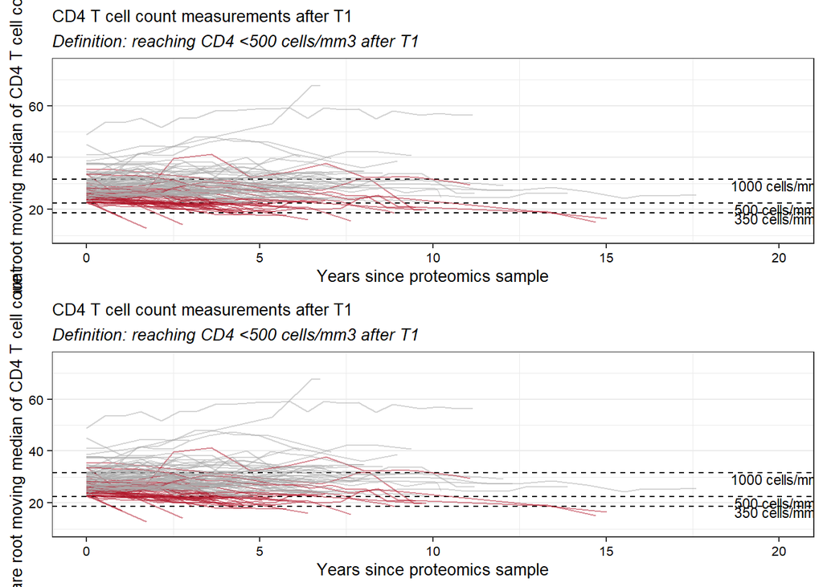

```r
cd4both <- ggplot(data=cd4_T1_500,aes(x=YEARS_SINCE_T1,y=sqrt(rollingmedian_index), group = SampleID))+
 geom_hline(yintercept=sqrt(350), linetype="dashed", color = "black")+
  geom_hline(yintercept=sqrt(500), linetype="dashed", color = "black")+
  geom_hline(yintercept=sqrt(1000), linetype="dashed", color = "black")+
  geom_line(aes(colour=IMMU_LOSS_EVER),alpha = 0.5,linewidth = 0.5)+ #LOSS_HYBRID
  scale_color_manual(values=c("darkgrey","#b2182b")) +
  theme_bw()+ theme(legend.position='none',
        panel.grid.major.x = element_blank(),
        axis.text = element_text(size = 8, color= "black"),
        axis.title = element_text(size = 10, color= "black",face = "plain"),
        plot.title = element_text(size = 10, color= "black"),
        plot.subtitle = element_text(size = 10, color= "black", face = "italic"))+
  labs(title = "CD4 moving median. Selection: only measurements after T1!",
       subtitle = "Definition: reaching CD4 <500 cells/mm3 after T1")+
  labs(title = "CD4 T cell count measurements after T1")+
  ylab("Square root moving median of CD4 T cell count")+
  xlab('Years since proteomics sample')+
  ylim(10,75) + xlim(0,20) +
  annotate("text", x=20, y=sqrt(275), label="350 cells/mm3", size = 3, color = "black") +
  annotate("text", x=20, y=sqrt(400), label="500 cells/mm3", size = 3, color = "black") +
  annotate("text", x=20, y=sqrt(850), label="1000 cells/mm3", size = 3, color = "black")

ggsave(paste0(working_dir, "Outputs/Supplements_FigureS4E_CD4_Lineplot_Loss42_noLoss96_sqrtCD4_afterT1_time.pdf")
       , gridExtra::grid.arrange(cd4both, cd4both, ncol =1),
       scale = 1, width = 4, height =6, units = 'in', dpi = 300)
```

##### Define end of follow-up for immuloss <500

Only in ECVC with CD4 > 500 at T1 (N=138).

Also join VL increase definition.

Define time and status for survival analyses.

```r
# add the other info
df_surv3 <- left_join(unique(cd4_T1_500[,c("SampleID", "IMMU_LOSS_D","IMMU_LOSS_EVER")]), df, by = "SampleID")

# define the FU_END time for immuloss <500
df_surv3 <- df_surv3 %>% mutate(FU_END_DATE_IMMULOSS = case_when(IMMU_LOSS_EVER == 1 ~ IMMU_LOSS_D,
                                                       IMMU_LOSS_EVER == 0 & ART == 1 ~ ART_START,
                                                       IMMU_LOSS_EVER == 0 & ART == 0 ~ LATEST_DATE),
                              FU_END_IMMULOSS = as.numeric((FU_END_DATE_IMMULOSS - T1_DATE)))

# select the same IDs for VL increase
df_surv4 <- df_surv[which(df_surv$SampleID %in% df_surv3$SampleID),]

# define time and status for survival items
df_surv3 <- df_surv3 %>% mutate(OUTCOME = "IMMULOSS",
                                TIME = FU_END_IMMULOSS,
                                STATUS = case_when(IMMU_LOSS_EVER == 0 ~ 0,
                                                   IMMU_LOSS_EVER == 1 ~ 1))

df_surv4 <- df_surv4  %>% mutate(OUTCOME = "VL_INCREASE",
                             TIME = FU_END_HYBRID,
                             STATUS = case_when(LOSS_HYBRID == 0 ~ 0,
                                                LOSS_HYBRID == 1 ~ 1))

# check survival items
Surv(df_surv3[,"TIME"], df_surv3[,"STATUS"])
```

```
##   [1]  184+ 1349+ 1015   798+ 2512+ 2871+   78+ 5659+  223  2518+ 1829+ 2220+
##  [13] 1727  1436  2855  2377+  336   524  2159+ 1673    23  2921+ 1552+ 1068+
##  [25]  951  1855+  756   148+ 2380+ 2786+ 6804+  630  1381+ 2336  1581+ 1781+
##  [37]  709    13+ 3770+ 2878+ 3451  3216+  843  2805+ 1802+ 1858   181+  721+
##  [49] 4402+ 2213+ 1350+  137   924  3535    15+  769+ 4159+    7+  493  1842
##  [61]  764  1379   590  3074+ 4077+  376+ 2186+ 3069+  895+ 1140  2311  2387+
##  [73]  863  3586+ 2705+  426+ 2483+ 1141  2071+ 4494+  902  1315+ 4141+ 1442+
##  [85] 2410+    9+  938  1976+ 1380+ 2182+ 1463   546  1634+ 2831+ 2375+ 1484+
##  [97] 3429+ 1970+ 3612+ 2764+  376  2007+ 1322+ 1341+ 2699+ 2467+ 2929+ 1158+
## [109] 5488   554  2363+ 2304+ 1141  3156  1782+ 1114  2716+  629+ 2226+ 1387+
## [121] 2583+ 1874+ 1715   457  2256+ 2159+ 2185+  532  1785+ 1278+ 2724+ 2472+
## [133] 2457+ 1597+ 2275+  506+ 3473+ 1537+
```

```r
Surv(df_surv4[,"TIME"], df_surv4[,"STATUS"])
```

```
##   [1]  184+ 1349+ 1015+  153  2512+ 1302    78+ 5075   223  1918  1050  2220+
##  [13] 1363  2485+ 1911  2377+  336  1159+ 1582  1673  1018  2921+ 1552+  205
##  [25] 1365  1485   133   148+ 2165  2786+ 3505   630  1381+ 2336  1581+  204
##  [37]  870    13+  574  2878+ 3592+ 2766  1549  2514  1507  2137   181   721+
##  [49] 4402+ 2213+  272  1334+ 2797+ 3551+   15+  403  2793     7+ 2936  2259+
##  [61] 1792+ 1570   590  3074+ 4077+  376+ 2186+ 1052   895+  937  2311+ 1310
##  [73]  863  3586+  843   146  1289  1141  2071+ 4494+ 1595+ 1315+ 2372  1442+
##  [85] 2410+    9+  742  1274   385  2182+ 1687+ 1315   765  1259  2375+ 1484+
##  [97] 3429+ 1970+ 2834  2764+  376   273   683  1341+ 1023  2467+ 2929+ 1158+
## [109] 3272  1382+ 2363+  491  2275   917    91   707  2716+  265  2177  1387+
## [121] 2583+  537  5374   457  2256+ 2159+ 1316  1269  1585  1278+ 2724+  985
## [133]  828  1597+  180   506+ 3473+ 1519
```

```r
# join the two
dfkm2 <- rbind(df_surv3[,c("SampleID","TIME","STATUS","OUTCOME")], df_surv4[,c("SampleID","TIME","STATUS","OUTCOME")])

summary(as.factor(dfkm2$OUTCOME))
```

```
##    IMMULOSS VL_INCREASE
##         138         138
```

```r
## what is the overlap?
temp <- left_join(df_surv3, df_surv4[,c("SampleID","LOSS_HYBRID","LOSS_HYBRID_DATE")], by = "SampleID")

table(temp$LOSS_HYBRID, temp$IMMU_LOSS_EVER)
```

```
##
##      0  1
##   0 52 13
##   1 44 29
```

```r
summary(temp$IMMU_LOSS_EVER)
```

```
##  0  1
## 96 42
```

```r
both <- temp[which(temp$LOSS_HYBRID ==1 & temp$IMMU_LOSS_EVER ==1),c("IMMU_LOSS_D","LOSS_HYBRID_DATE","FU_END_DATE")]
both <- both %>% mutate(relative = case_when(both$IMMU_LOSS_D < both$LOSS_HYBRID_DATE ~ "CD4 first",
                                     both$IMMU_LOSS_D > both$LOSS_HYBRID_DATE ~ "VL first",
                                     both$IMMU_LOSS_D == both$LOSS_HYBRID_DATE ~ "Simultaneous"))
summary(as.factor(both$relative))
```

```
##    CD4 first Simultaneous     VL first
##           11           10            8
```

## 0.6 Kaplan meier with CD4 decrease and VL increase

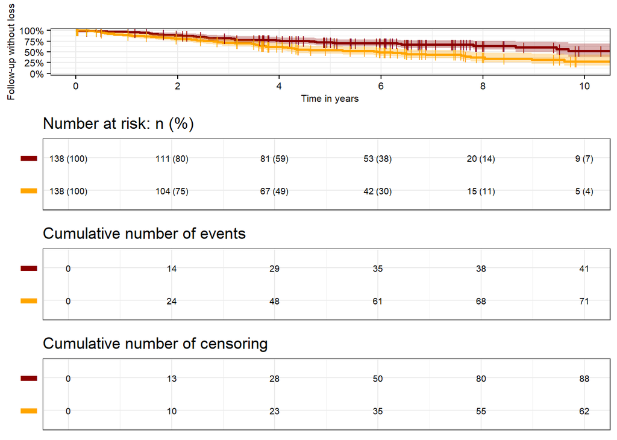

```r
# kaplan meier fit and plot
km2_fit <- survfit(Surv(dfkm2[,"TIME"], dfkm2[,"STATUS"]) ~ OUTCOME, data=dfkm2) # use ~1 if you want to indicate there is no grouping variable.

km2 <- ggsurvplot(km2_fit,censor.size=3, censor.shape=124,conf.int = T,
           surv.scale = "percent", xlim = c(0,10*365.25), #ylim = c(0.75,1),
            break.y.by = 0.25, # y-axis tick marks
            break.x.by = 365.25*2, # x-axis tick marks
            xscale = "d_y", # transform labels from days to years
            ylab = "Follow-up without loss", font.y = c(8,"plain","black"),
            xlab = "Time in years", font.x = c(8,"plain","black"),
            font.tickslab = c(8,"plain","black"),
            title = "",
            legend = "none",
            ggtheme = theme_bw(),
            cumevents = TRUE, # table for cumulative events
           fontsize = 2.5,
           cumcensor = TRUE, # table for cumulative censoring
                  risk.table = "abs_pct", # absolute with percentage
                  tables.height = 0.25, # default is 0.25
                  palette = c("darkred","orange"), # add multiple colors if more group levels
                  #risk.table.fontsize =1.5, # redundant because of fontsize argument above
                  tables.theme = clean_theme(),
                  tables.y.text = F)
km2
```

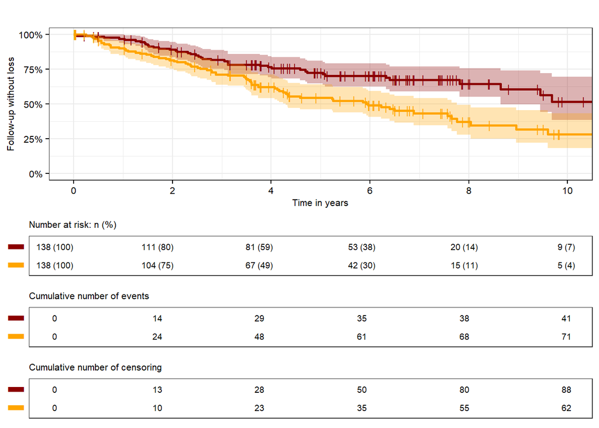

```r
km2.1 <- gridExtra::grid.arrange(km2$plot,
                                 km2$table + theme(plot.title = element_text(size = 8,face="plain"), panel.grid = element_line(colour="white")),
                                 km2$cumevents + theme(plot.title = element_text(size = 8,face="plain"), panel.grid = element_line(colour="white")),
                                 km2$ncensor.plot + theme(plot.title = element_text(size = 8,face="plain"), panel.grid = element_line(colour="white")),
                               layout_matrix = cbind(c(1,1,1,1,1,1,2,2,3,3,4,4)))
```

```r
ggsave(paste0(working_dir, "Outputs/Supplements_FigureS4E_CD4_LOSS_CD4below500_KaplanMeier_Loss42_noLoss96_.pdf")
       ,km2.1,
       scale = 1, width = 4, height =5, units = 'in', dpi = 300)
```

### 0.6.1 Cox regression CD4 < 500

Power is reduced because we only have N=138 individuals

```r
# Join with processed clinical data
dfcox5 <- df_surv3 # TIME AND STATUS DEFINED ABOVE

###### addendum 24-10-2024 to export prepared data as RDS object
tempdir <- "C:/Users/accou/Downloads/" #"C:/Users/accou/Documents/PHD_2_projects/7_Predictionmodels_SHMOlink/Input/"

saveRDS(dfcox5, file = paste0(tempdir, "OlinkATHENA_ARTnaiveECVC_immunoloss_prepared.rds"))
rm(tempdir)
######


# double check the survival items: # this is the most important thing: TIME and STATUS must be coded correctly and the survival item must have the format of time (in this case in days) with an additional "+" sign if censored
Surv(dfcox5[,"TIME"],dfcox5[,"STATUS"])
```

```
##   [1]  184+ 1349+ 1015   798+ 2512+ 2871+   78+ 5659+  223  2518+ 1829+ 2220+
##  [13] 1727  1436  2855  2377+  336   524  2159+ 1673    23  2921+ 1552+ 1068+
##  [25]  951  1855+  756   148+ 2380+ 2786+ 6804+  630  1381+ 2336  1581+ 1781+
##  [37]  709    13+ 3770+ 2878+ 3451  3216+  843  2805+ 1802+ 1858   181+  721+
##  [49] 4402+ 2213+ 1350+  137   924  3535    15+  769+ 4159+    7+  493  1842
##  [61]  764  1379   590  3074+ 4077+  376+ 2186+ 3069+  895+ 1140  2311  2387+
##  [73]  863  3586+ 2705+  426+ 2483+ 1141  2071+ 4494+  902  1315+ 4141+ 1442+
##  [85] 2410+    9+  938  1976+ 1380+ 2182+ 1463   546  1634+ 2831+ 2375+ 1484+
##  [97] 3429+ 1970+ 3612+ 2764+  376  2007+ 1322+ 1341+ 2699+ 2467+ 2929+ 1158+
## [109] 5488   554  2363+ 2304+ 1141  3156  1782+ 1114  2716+  629+ 2226+ 1387+
## [121] 2583+ 1874+ 1715   457  2256+ 2159+ 2185+  532  1785+ 1278+ 2724+ 2472+
## [133] 2457+ 1597+ 2275+  506+ 3473+ 1537+
```

```r
# Run Cox regression immu loss
olinkcolumns2 <- c(grep("GP2",colnames(dfcox5)):grep("NFU1",colnames(dfcox5)))
res3 <- data.frame()
for (i in olinkcolumns2) {
    cox.res <- coxph(Surv(dfcox5[,"TIME"],dfcox5[,"STATUS"]) ~ dfcox5[,i]
                     + SEX + AGE + CENTER_EMC + CENTER_OLVG + CENTER_UMCU + STORAGE_TIME,
                     data = dfcox5)
    x <- summary(cox.res)

    newrow =
        cbind(
        as.data.frame(colnames(dfcox5)[i], nm = "PROTEIN"), # protein name
        as.data.frame(x$coef[1,"coef"],nm = "BETA"), # beta
        as.data.frame(x$coef[1,"exp(coef)"],nm = "HR"), # Hazard ratio
        as.data.frame(x$conf.int[1,"lower .95"],nm = "LOWER"),
        as.data.frame(x$conf.int[1,"upper .95"],nm = "UPPER"), # 95% CI of the Hazard ratio
        as.data.frame(x$coef[1,"Pr(>|z|)"], nm = "RAW_P") # P-value of coefficient
        )
    res3 <- rbind(res3,newrow)
}
res3$FDR_P <- p.adjust(res3$RAW_P, method = 'BH')
res3[order(res3$RAW_P),]
```

```
##                PROTEIN          BETA        HR      LOWER      UPPER
## 89                 DDC  7.933296e-01 2.2107451 1.38377112  3.5319382
## 1359             FCRL5  6.164534e-01 1.8523469 1.25254245  2.7393794
## 191              ICAM3  1.269330e+00 3.5584676 1.55840148  8.1254363
## 1393            MEGF11 -1.721996e+00 0.1787092 0.05624621  0.5678065
## 396              FCRL3  6.817220e-01 1.9772797 1.23957682  3.1540077
## 852              CALB1 -5.492778e-01 0.5773666 0.39601434  0.8417680
## 403                AMN -9.469418e-01 0.3879256 0.20143340  0.7470769
## 590            SCGB1A1 -7.159911e-01 0.4887075 0.29532670  0.8087147
## 1205              NAAA  4.419338e-01 1.5557127 1.13635634  2.1298267
## 468               LY75  1.117137e+00 3.0560910 1.37348558  6.7999930
## 1030             LYPD3 -1.048988e+00 0.3502920 0.16402024  0.7481056
## 387             IL1RL2 -7.169285e-01 0.4882496 0.28973809  0.8227695
## 1595            BPIFB2 -6.692701e-01 0.5120822 0.31327308  0.8370595
## 585                LY9  1.174755e+00 3.2373494 1.34787145  7.7755422
```

[output cut: 4827 more lines]

```r
###### addendum 24-10-2024 to export prepared data as RDS object
tempdir <- "C:/Users/accou/Downloads/" #"C:/Users/accou/Documents/PHD_2_projects/7_Predictionmodels_SHMOlink/Input/"

saveRDS(res3, file = paste0(tempdir, "OlinkATHENA_ARTnaiveECVC_immunoloss_coxregr_sumstats.rds"))
rm(tempdir)
######
```

## 0.7 Volcano plot

```r
# add a grouping column for coloring by significance; default value is "not significant"
res3 <- res3 %>% mutate(group= case_when(FDR_P < 0.05 ~ "FDR Significant",
                                               RAW_P < 0.05 & FDR_P > 0.05 ~ "Nominal Significant",
                                               RAW_P > 0.05 ~ "NotSignificant"
                                               ))

# add a text label if 'FDR-P <0.05', or if 'RAW-P <0.05 but HR >2', or if CRTAM, LY9, CD6, VAT1.
for (i in 1:nrow(res3)){
  if(res3$FDR_P[i] < 0.05 | # 'FDR-P <0.05'
          res3$RAW_P[i] < 0.01 |
     #(res3$RAW_P[i] < 0.01 & res3$HR[i] > 3) | # 'RAW-P <0.05 but HR >3'
     #(res3$RAW_P[i] < 0.01 & res3$HR[i] <0.3) | # 'RAW-P <0.05 but HR <0.3'
     (res3$PROTEIN[i] %in% c("CRTAM","LY9","CD6","VAT1") # CRTAM, LY9, CD6, VAT1
     ))
  {res3$LABEL[i] <- res3$PROTEIN[i]} else
  {res3$LABEL[i] <- ""}}
res3[order(res3$FDR_P),]
```

```
##                PROTEIN          BETA        HR      LOWER      UPPER
## 1                  GP2 -8.713346e-02 0.9165548 0.67490585  1.2447257
## 2                WASF1  1.037134e-01 1.1092824 0.85617184  1.4372203
## 3                  HK2  1.928257e-02 1.0194697 0.77876467  1.3345732
## 4               VSTM2L -9.751244e-01 0.3771454 0.17655970  0.8056124
## 5                 TIA1  7.042526e-02 1.0729644 0.89278504  1.2895070
## 6             MPHOSPH8 -1.594401e-02 0.9841824 0.73292068  1.3215824
## 7               HNRNPK  9.060478e-02 1.0948362 0.90309838  1.3272821
## 8                CEBPB -6.177599e-01 0.5391508 0.28239524  1.0293502
## 9                  VIM  1.485503e-02 1.0149659 0.69112785  1.4905430
## 10               CHEK2  7.138074e-02 1.0739901 0.77865320  1.4813458
## 11               CRHR1 -5.113436e-02 0.9501510 0.76143899  1.1856326
## 12                TSLP  1.291364e-01 1.1378453 0.77812843  1.6638539
## 13               MFAP3 -1.809539e-01 0.8344738 0.55497482  1.2547355
## 14                CTF1 -1.306508e-01 0.8775242 0.67924073  1.1336903
```

[output cut: 4827 more lines]

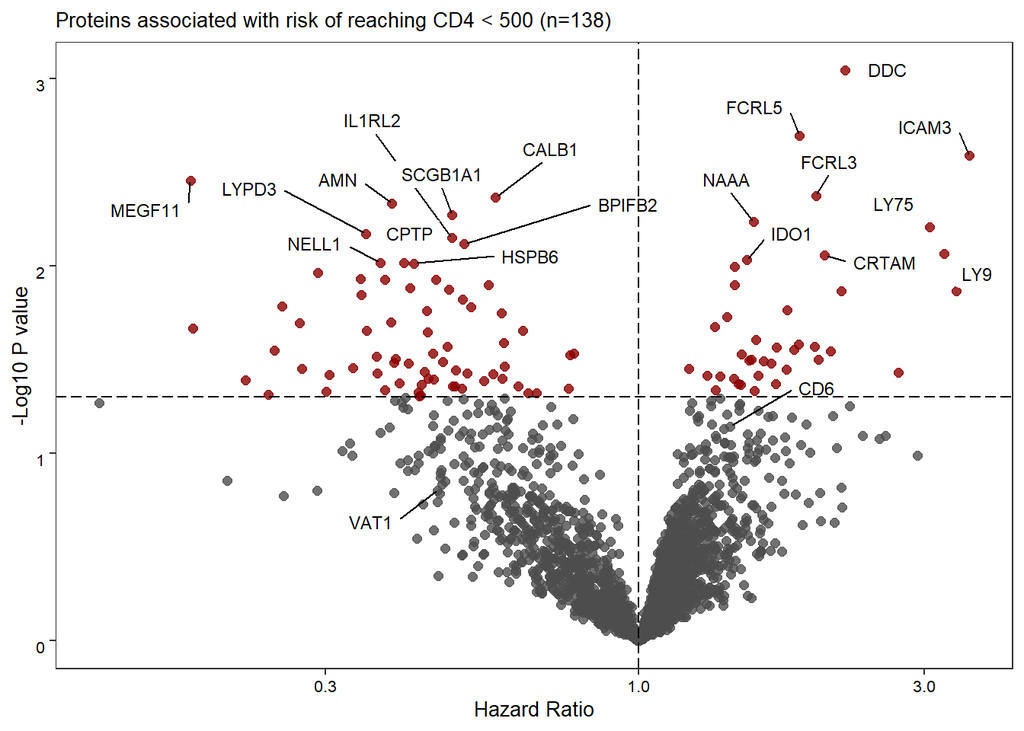

```r
# make the volcano plot
options(ggrepel.max.overlaps = Inf)
ggplot(res3, aes(x=HR, y=-log10(RAW_P))) +
  geom_point(aes(color=group), alpha=0.8, size=2) +
  scale_color_manual(values=c("darkred","#4d4d4d")) +
  theme_bw() + # size of plotting window
  theme(legend.background=element_rect(),
        plot.title=element_text(angle=0, size=10, face="plain", vjust=1),
        panel.grid.major=element_blank(), #Remove gridlines
        panel.grid.minor=element_blank(), #Remove gridlines
        axis.text.x=element_text(angle=0, size=8, color= "black", vjust=1),
        axis.text.y=element_text(angle=0, size=8, color= "black", vjust=1),
        axis.title=element_text(size=10),
        legend.position = "none") +
  # guides(colour = guide_legend(override.aes=list(size=2.5))) + #  Change the size of the icons/symbols in the legend
  xlab("Hazard Ratio") +
  ylab("-Log10 P value") +
  scale_x_continuous(trans = 'log10')+ #, limits = c(0.15,5.5)) +
  ggtitle("Proteins associated with risk of reaching CD4 < 500 (n=138)" ) +
  geom_label_repel(  #Add the text labels
    label.size = NA, #Size of label border, in mm.
    box.padding = unit(0.45, "lines"),
    label.padding = 0.25, # Amount of padding around label, as unit or number.
    label.r = 0.15, #Radius of rounded corners,
    size = 3, aes(label = LABEL,hjust = .5))+
  #ylim(0, 3) + # limits of the graph
  geom_vline(xintercept=c(1), linetype="longdash", colour="black", linewidth=0.4) + # Add a vertical line for Estimate change cut-offs
  geom_hline(yintercept=-log10(0.05), linetype="longdash", colour="black", linewidth=0.4) #Add a horizontal line for P-value cut-off
```

```r
ggsave(paste0(working_dir, "Outputs/Supplements_FigureS4F_CD4COX_Volcano_label_0.01RAWP_agesexcenterstorage.pdf"), plot = last_plot(), device = NULL, path = NULL,scale = 1, width = 4, height =3.5, units = 'in', dpi = 300)

# write results to excel file
openxlsx::write.xlsx(res3,paste0(working_dir, "Outputs/Supplements_LOSS_Cox_CD4LOSS_96Kept_42Lost_2420_agesexcenterstorage.xlsx"))
```

## 0.8 Specific forest plots Figure 3D

Include all proteins that are FDR-significant for predicting virological loss OR VL increase >1000 c/mL.

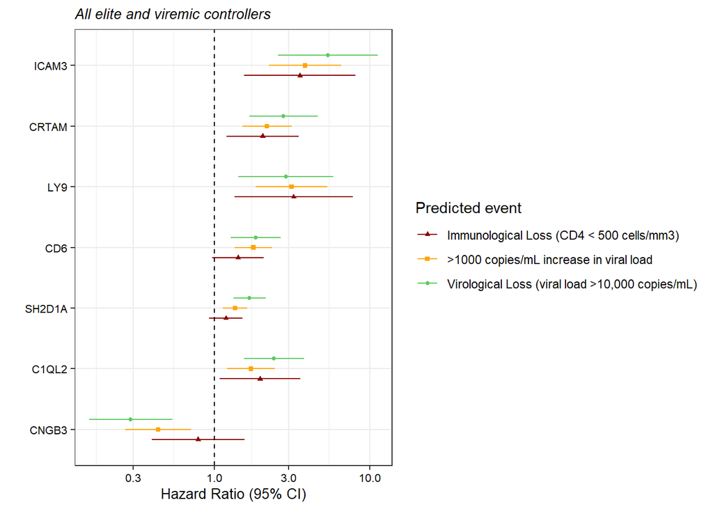

```r
# select the proteins and join together
virloss <- res1 %>% filter(PROTEIN %in% c("ICAM3","CRTAM","LY9", "CD6","SH2D1A","C1QL2","CNGB3")) %>%
  mutate(OUTCOME = "Virological Loss (viral load >10,000 copies/mL)")
vlincrease <- res2 %>% filter(PROTEIN %in% c("ICAM3","CRTAM","LY9", "CD6","SH2D1A","C1QL2","CNGB3"))%>%
  mutate(OUTCOME = ">1000 copies/mL increase in viral load")
cd4less500 <- res3 %>% filter(PROTEIN %in% c("ICAM3","CRTAM","LY9", "CD6","SH2D1A","C1QL2","CNGB3"))%>%
  mutate(OUTCOME = "Immunological Loss (CD4 < 500 cells/mm3)")

forestall <- rbind(virloss, vlincrease, cd4less500)

forestall$OUTCOME <- factor(forestall$OUTCOME, levels = unique(forestall$OUTCOME)[c(3,2,1)])
forestall$PROTEIN <- factor(forestall$PROTEIN, levels = rev(c("ICAM3","CRTAM","LY9", "CD6","SH2D1A","C1QL2","CNGB3")))

# ALL
ggplot(forestall, aes(x = HR, y = PROTEIN, color = OUTCOME)) +
   geom_pointrange(aes(xmin = LOWER, xmax = UPPER, shape = OUTCOME),
                   position = position_dodge(width = 0.5), size = 0.2, linewidth = 0.5) +
   geom_vline(xintercept = 1, linetype = 2) +
  theme_bw() + ylab("") + xlab("Hazard Ratio (95% CI)") +
  theme(strip.placement = "outside",
       strip.text= element_text(angle = 0, size = 6),
       strip.background = element_blank(),
       axis.title = element_text(size = 10, face = "plain",colour= "black"),
       axis.text.y = element_text(size = 8, face = "plain",colour= "black"),
       axis.text.x = element_text(size = 8, face= "plain",colour = "black"),
       legend.position = "right",
       plot.title = element_text(size = 10, face = "italic"),
       panel.spacing = unit(0, "mm")) +
  ggtitle("All elite and viremic controllers")+
  scale_x_continuous(trans='log10')+#,limits = c(0.3,7))+
  scale_color_manual(values = rev(c("#5ec962","orange","darkred")),name = "Predicted event") +
  scale_shape_manual(values = c(17,15,16), name = "Predicted event")
```

```r
ggsave(paste0(working_dir, "Outputs/Figure3D_predict_CRTAMLY9CD6_91LOSS_90NOLOSS_FORESTPLOT.pdf"),
       width = 5.5, height = 3.5, units = "in") # 1/8 A4 size
```

## 0.9 Risk of detectable VL after T1 in 36 EC: Figure 3E

**Sensitivity analysis with EC first detectable**

I run cox regression for EC only. Next, I run cox regression again, but for the EC who are still VL <50 c/mL at T1.

CRTAM and CD6 also significantly predict which EC will become detectable, but the 95%CI are very large. To limit the risk of overfitting I only correct for sex and age here.

```r
# define the FU_END date for both definitions
dfsurvEC <- df_surv %>% filter(NONVIREMIC == 1) %>%
  mutate(FU_END_ECDETECTDATE = case_when(FIRSTDETECT_EVER  == 1 ~ FIRSTDETECT_DATE,
                                     FIRSTDETECT_EVER == 0 & ART == 1 ~ ART_START,
                                     FIRSTDETECT_EVER == 0 & ART == 0 ~ LATEST_DATE)) %>%
# recalculate time FU_END for both definitions in days
  mutate(FU_END_ECDETECT = as.numeric(FU_END_ECDETECTDATE - T1_DATE)) %>%
# if TIME == 0, set to 1, as is normally done in cox regressions
  mutate(FU_END_ECDETECT = case_when(FU_END_ECDETECT != 0 ~ FU_END_ECDETECT,
                                     FU_END_ECDETECT == 0 ~ 1))

# join with olink data
dfsurvEC <- dfsurvEC %>%
  # define time and status for survival analysis
  mutate(TIME = FU_END_ECDETECT,
         STATUS = case_when(FIRSTDETECT_EVER == 0 ~ 0,
                            FIRSTDETECT_EVER == 1 ~ 1))

# check the survival item
Surv(dfsurvEC[,"TIME"],dfsurvEC[,"STATUS"])
```

```
##  [1]    1  2512  1827  2921+  442     1     1  2213+   15+ 4077+  376+    1
## [13]    1   714  2182+  539  2375+ 1484+ 1970+  683  2467+ 2733   909   181+
## [25] 2177  2583+    1  2256+ 2159+  213+ 1987+ 1278+ 2724+ 1597+  506+ 3473+
```

```r
# check the groups
summary(as.factor(dfsurvEC$STATUS))
```

```
##  0  1
## 21 15
```

```r
summary(as.factor(dfsurvEC$FIRSTDETECT_EVER))
```

```
##  0  1
## 21 15
```

```r
# Check the main covariates
table(dfsurvEC$CENTER,dfsurvEC$STATUS)
```

```
##
##        0 1
##   EMC  4 3
##   LUMC 0 0
##   MSZ  3 5
##   OLVG 9 6
##   RAD  3 1
##   UMCU 2 0
```

```r
table(dfsurvEC$SEX,dfsurvEC$STATUS)
```

```
##
##           0  1
##   FEMALE 13  2
##   MALE    8 13
```

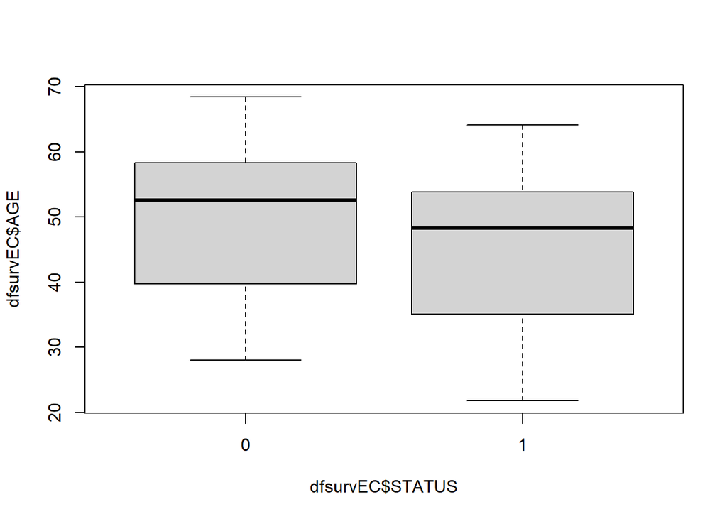

```r
boxplot(dfsurvEC$AGE~dfsurvEC$STATUS)
```

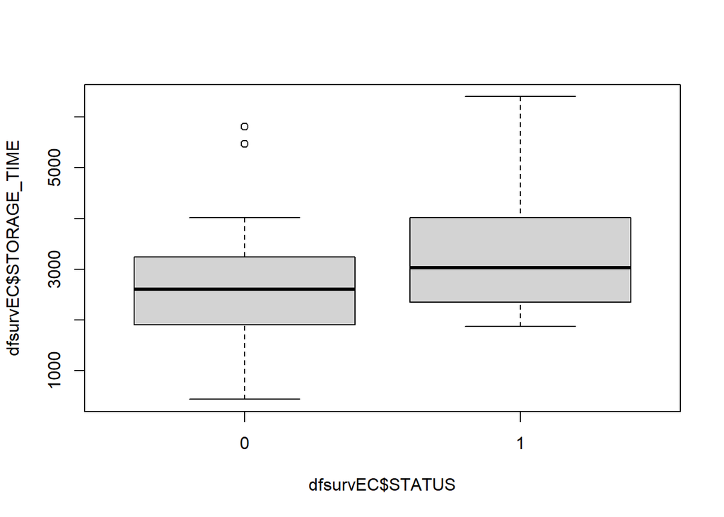

```r
boxplot(dfsurvEC$STORAGE_TIME~dfsurvEC$STATUS)
```

```r
# Run cox regression for CRTAM, LY9 and CD6 and other FDR significant proteins in main analyses
forestecdetect <- data.frame()
for (protein in c("ICAM3","CRTAM","LY9", "CD6","SH2D1A","C1QL2","CNGB3")){
    cox.res <- coxph(Surv(dfsurvEC[,"TIME"],dfsurvEC[,"STATUS"]) ~ dfsurvEC[,protein]
                     + SEX + AGE
                     ,data = dfsurvEC)
    x <- summary(cox.res)

    newrow =
        cbind(
        as.data.frame(protein, nm = "PROTEIN"), # protein name
        as.data.frame(x$coef[1,"coef"],nm = "BETA"), # beta
        as.data.frame(x$coef[1,"exp(coef)"],nm = "HR"), # Hazard ratio
        as.data.frame(x$conf.int[1,"lower .95"],nm = "LOWER"),
        as.data.frame(x$conf.int[1,"upper .95"],nm = "UPPER"), # 95% CI of the Hazard ratio
        as.data.frame(x$coef[1,"Pr(>|z|)"], nm = "RAW_P"), # P-value of coefficient
        as.data.frame("All EC (n=36)", nm = "SELECTION")
        )
    forestecdetect <- rbind(forestecdetect,newrow) }
forestecdetect
```

```
##   PROTEIN       BETA         HR     LOWER     UPPER        RAW_P     SELECTION
## 1   ICAM3  2.6073415 13.5629464 3.7372780 49.221256 7.352163e-05 All EC (n=36)
## 2   CRTAM  1.5060380  4.5088313 2.0292150 10.018436 2.180159e-04 All EC (n=36)
## 3     LY9  2.6254199 13.8103723 3.5941235 53.066173 1.320316e-04 All EC (n=36)
## 4     CD6  1.1855016  3.2723280 1.6476940  6.498859 7.079836e-04 All EC (n=36)
## 5  SH2D1A  0.2262932  1.2539433 0.9340098  1.683466 1.321397e-01 All EC (n=36)
## 6   C1QL2  0.4133328  1.5118481 0.5534395  4.129963 4.201630e-01 All EC (n=36)
## 7   CNGB3 -0.6691348  0.5121515 0.1202964  2.180441 3.653041e-01 All EC (n=36)
```

```r
# add cox results for filtered
dfsurvEC2 <- dfsurvEC %>% filter(T1_VL == 0)
for (protein in c("ICAM3","CRTAM","LY9", "CD6","SH2D1A","C1QL2","CNGB3")){
    cox.res <- coxph(Surv(dfsurvEC2[,"TIME"],dfsurvEC2[,"STATUS"]) ~ dfsurvEC2[,protein]
                     + SEX + AGE
                     ,data = dfsurvEC2)
    x <- summary(cox.res)
    newrow =
        cbind(
        as.data.frame(protein, nm = "PROTEIN"), # protein name
        as.data.frame(x$coef[1,"coef"],nm = "BETA"), # beta
        as.data.frame(x$coef[1,"exp(coef)"],nm = "HR"), # Hazard ratio
        as.data.frame(x$conf.int[1,"lower .95"],nm = "LOWER"),
        as.data.frame(x$conf.int[1,"upper .95"],nm = "UPPER"), # 95% CI of the Hazard ratio
        as.data.frame(x$coef[1,"Pr(>|z|)"], nm = "RAW_P"), # P-value of coefficient
        as.data.frame("EC <50 at sampling (n=30)", nm = "SELECTION")
        )
    forestecdetect <- rbind(forestecdetect,newrow) }
forestecdetect
```

```
##    PROTEIN        BETA         HR     LOWER     UPPER        RAW_P
## 1    ICAM3  2.60734154 13.5629464 3.7372780 49.221256 7.352163e-05
## 2    CRTAM  1.50603799  4.5088313 2.0292150 10.018436 2.180159e-04
## 3      LY9  2.62541992 13.8103723 3.5941235 53.066173 1.320316e-04
## 4      CD6  1.18550164  3.2723280 1.6476940  6.498859 7.079836e-04
## 5   SH2D1A  0.22629323  1.2539433 0.9340098  1.683466 1.321397e-01
## 6    C1QL2  0.41333282  1.5118481 0.5534395  4.129963 4.201630e-01
## 7    CNGB3 -0.66913484  0.5121515 0.1202964  2.180441 3.653041e-01
## 8    ICAM3  1.79528332  6.0211804 0.6763819 53.600802 1.075199e-01
## 9    CRTAM  1.39205848  4.0231231 0.8816925 18.357329 7.227377e-02
## 10     LY9  2.00982022  7.4619757 0.5824130 95.604118 1.224588e-01
## 11     CD6  1.28737906  3.6232777 0.9325519 14.077652 6.301000e-02
## 12  SH2D1A  0.27200091  1.3125882 0.8866054  1.943241 1.742274e-01
## 13   C1QL2 -0.22695297  0.7969583 0.1983704  3.201801 7.490739e-01
## 14   CNGB3 -0.05979647  0.9419562 0.1886737  4.702731 9.418955e-01
##                    SELECTION
## 1              All EC (n=36)
## 2              All EC (n=36)
## 3              All EC (n=36)
## 4              All EC (n=36)
## 5              All EC (n=36)
## 6              All EC (n=36)
## 7              All EC (n=36)
## 8  EC <50 at sampling (n=30)
## 9  EC <50 at sampling (n=30)
## 10 EC <50 at sampling (n=30)
## 11 EC <50 at sampling (n=30)
## 12 EC <50 at sampling (n=30)
## 13 EC <50 at sampling (n=30)
## 14 EC <50 at sampling (n=30)
```

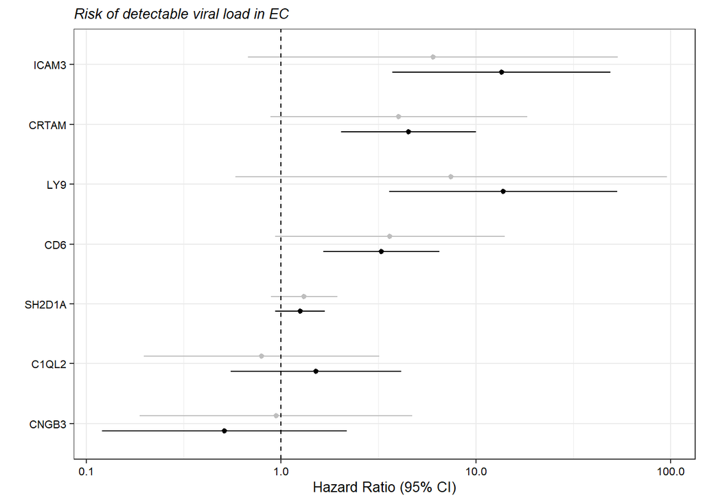

```r
forestecdetect$PROTEIN <- factor(forestecdetect$PROTEIN, levels = rev(c("ICAM3","CRTAM","LY9", "CD6","SH2D1A","C1QL2","CNGB3")))

forestecdetect %>% filter(PROTEIN %in% c("ICAM3","CRTAM","LY9", "CD6","SH2D1A","C1QL2","CNGB3")) %>%
   ggplot(aes(HR, PROTEIN, color = SELECTION)) +
   geom_pointrange(aes(xmin = LOWER, xmax = UPPER),linewidth = 0.5, size = .2,
                   position = position_dodge(width = 0.5)) +
   geom_vline(xintercept = 1, linetype = 2) +
  theme_bw() + ylab("") + xlab("Hazard Ratio (95% CI)") +
  theme(strip.placement = "outside",
       strip.text= element_text(angle = 0, size = 6),
       strip.background = element_blank(),
       axis.title = element_text(size = 10, face = "plain",colour= "black"),
       axis.text.y = element_text(size = 8, face = "plain",colour= "black"),
       axis.text.x = element_text(size = 8, face= "plain",colour = "black"),
       legend.position = "none",
       plot.title = element_text(size = 10, face = "italic"),
       panel.spacing = unit(0, "mm")) +
  ggtitle("Risk of detectable viral load in EC")+
  scale_x_continuous(trans='log10') +
  scale_color_manual(values = c("black","grey"),name="")
```

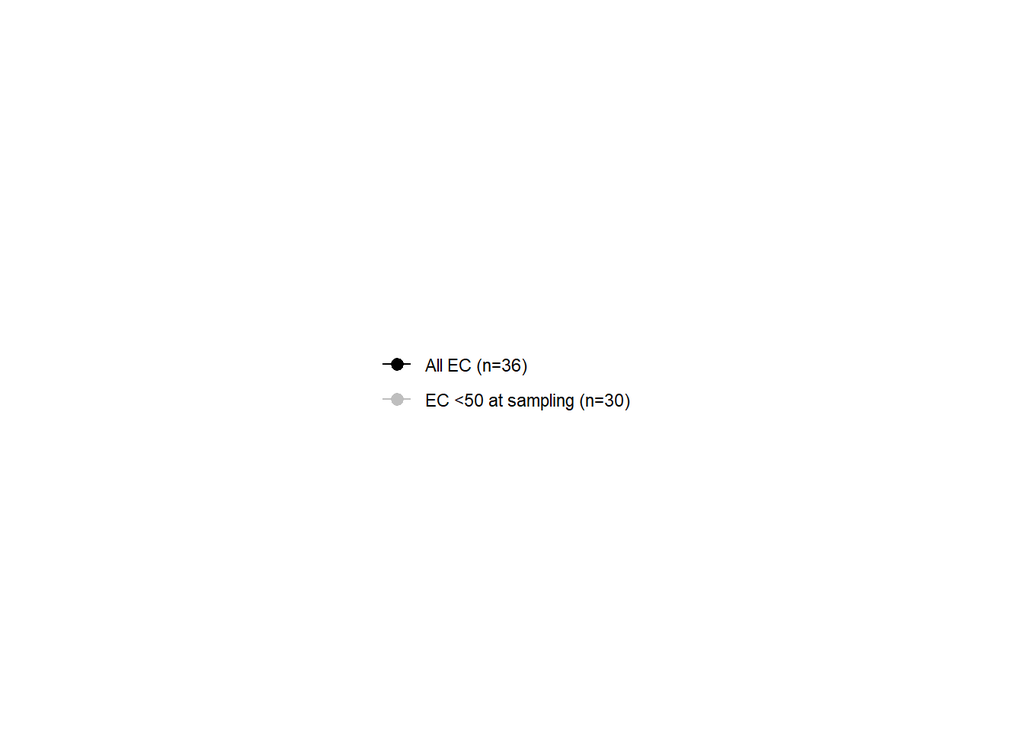

```r
ggsave(paste0(working_dir, "Outputs/Figure3E_LOSS_ECDETECTABLE_CRTAMLY9CD6ETC_15LOSS_21NOLOSS_FORESTPLOT.pdf"),
       width = 3, height = 3.25, units = "in") # 1/8 A4 size

# add the legend
as_ggplot(get_legend(forestecdetect %>% filter(PROTEIN %in% c("ICAM3","CRTAM","LY9", "CD6","SH2D1A","C1QL2","CNGB3")) %>%
   ggplot(aes(HR, PROTEIN, color = SELECTION)) +
   geom_pointrange(aes(xmin = LOWER, xmax = UPPER),
                   position = position_dodge(width = 0.5)) +
  theme_bw() + ylab("") + xlab("Hazard Ratio (95% CI)") +
  theme(strip.background = element_blank(),legend.position = "right")+
  scale_color_manual(values = c("black","grey"),name="")))
```

```r
ggsave(paste0(working_dir, "Outputs/Figure3E_LEGEND.pdf"),
       width = 2, height = 2, units = "in") # 1/8 A4 size

# write results to excel file
openxlsx::write.xlsx(forestecdetect,paste0(working_dir, "Outputs/Supplements_Figure3E_LOSSCOX_ECDETECTABLE_CRTAMLY9CD6ETC_15LOSS_21NOLOSS_agesex.xlsx"))
```